# Project_Data_Analysis

Davoud Kalantari

2025-08-01

```r
# carico il dataset processato

seed <- read.table("C:/Users/David/Desktop/DATA SCIENCE MAGISTRALE/Data Analysis/Davoud.K_Project/seeds/seeds_dataset.txt", header = FALSE)

colnames(seed) <- c("A","P","C","LK","WK","A_Coef","LKG","target")
```

## DATASET EXPLANATION : seed

This report is about the “Seed” dataset contained in  
https://archive.ics.uci.edu/dataset/236/seeds.

It contains measurements of geometrical properties of kernels belonging to three different varieties of wheat (Kama, Rosa and Canadian).  
High quality visualization of the internal kernel structure was detected using a soft X-ray technique.  
The kernels were randomly selected for the experiment conducted at the Institute of Agrophysics of the Polish Academy of Sciences in Lublin.

To construct the data, seven geometric parameters (variables) of wheat kernels were measured:

1. **Area A (mm²)**
2. **Perimeter P (mm)**
3. **Compactness C**: the geometric compactness of the shape of the kernel  
   $C = \frac{4 \pi A}{P^2}$
4. **Length of kernel LK (mm)**
5. **Width of kernel WK (mm)**
6. **Asymmetry coefficient A_Coef**: the asymmetry of the shape of the kernel
7. **Length of kernel groove LKG (mm)**

All of these parameters are real-valued continuous variables.

In addition we have the external categorical variable:  
8. **Class target**,  
that describes the three different varieties of wheat (Kama, Rosa, and Canadian).

The number of observations for each class is balanced.  
Briefly, there are 210 observations with 7 continuous input variables and 1 categorical output variable.

```r
str(seed)
```

```
## 'data.frame':    210 obs. of  8 variables:
##  $ A     : num  15.3 14.9 14.3 13.8 16.1 ...
##  $ P     : num  14.8 14.6 14.1 13.9 15 ...
##  $ C     : num  0.871 0.881 0.905 0.895 0.903 ...
##  $ LK    : num  5.76 5.55 5.29 5.32 5.66 ...
##  $ WK    : num  3.31 3.33 3.34 3.38 3.56 ...
##  $ A_Coef: num  2.22 1.02 2.7 2.26 1.35 ...
##  $ LKG   : num  5.22 4.96 4.83 4.8 5.17 ...
##  $ target: int  0 0 0 0 0 0 0 0 0 0 ...
```

```r
summary(seed$A)
```

```
##    Min. 1st Qu.  Median    Mean 3rd Qu.    Max.
##   10.59   12.27   14.36   14.85   17.30   21.18
```

verify that no rows have missing values (NA).

```r
# Import dataset after saving it in the working directory
# (already loaded above)

# Verifica se ci sono righe con valori mancanti nel dataset
righe_complete <- complete.cases(seed)

# Conta il numero di righe con valori mancanti
numero_righe_mancanti <- sum(!righe_complete)

# Stampa il numero di righe con valori mancanti
print(numero_righe_mancanti)
```

```
## [1] 0
```

## UNIVARIATE ANALYSIS

### 1. Area

```r
#univariate analysis
summary(seed$A)
```

```
##    Min. 1st Qu.  Median    Mean 3rd Qu.    Max.
##   10.59   12.27   14.36   14.85   17.30   21.18
```

```r
sd(seed$A)
```

```
## [1] 2.909699
```

```r
#coeffiient of variation
sd(seed$A)/mean(seed$A)
```

```
## [1] 0.195972
```

Now we analuze the **mode** that assume 3 different threemodal distributiion

```r
# Frequency table and mode computation
frequencyArea <- table(seed$A)
names(frequencyArea)[frequencyArea == max(frequencyArea)]
```

```
## [1] "11.23" "14.11" "15.38"
```

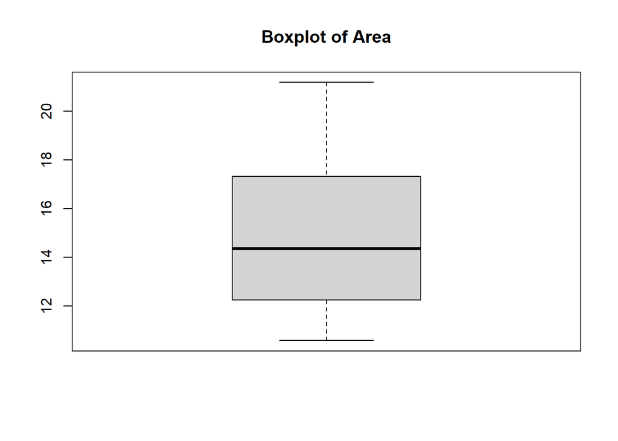

```r
# Boxplot for Area

boxplot(seed$A, main= "Boxplot of Area")
```

The boxplot of the Area variable does not display any **significant outliers**.  
All the data points fall within a regular interval, suggesting that the distribution is reasonably uniform.  
The median is located near the center of the box, indicating a fairly **symmetric distribution**.

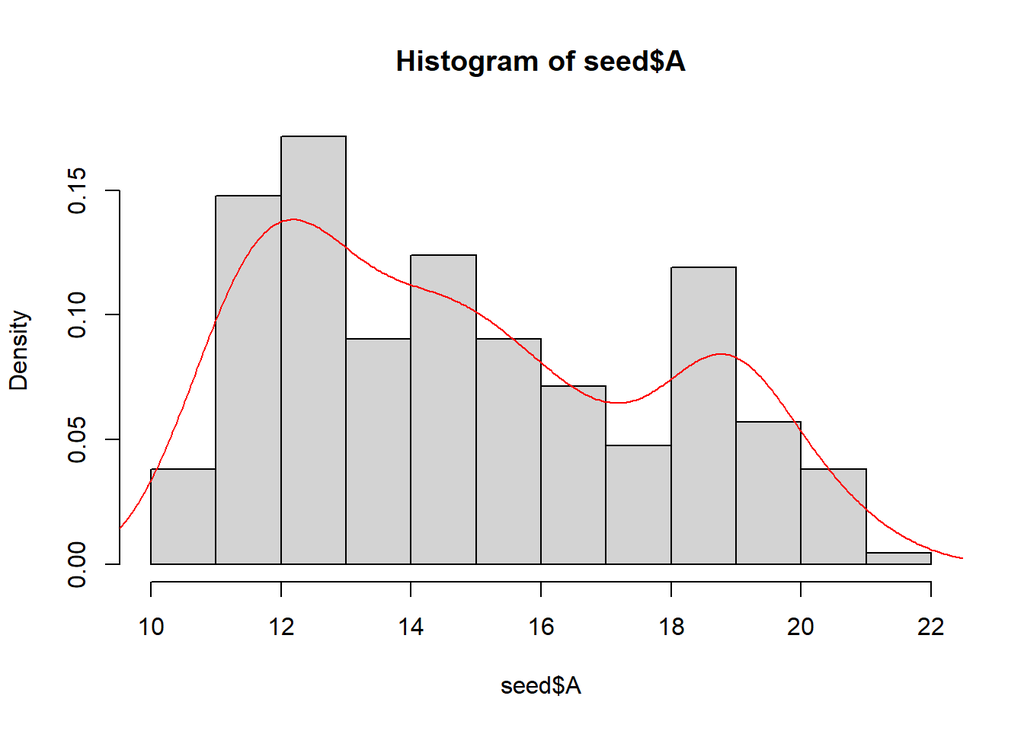

```r
# Histogram with kernel density estimation
hist(seed$A,freq=FALSE)
#kernel smoothing
lines(density(seed$A), col="red")
```

The histogram, combined with the overlaid kernel density curve, provides a clear visualization of how the values of **Area** are distributed.  
The distribution appears slightly asymmetric but without extreme deviations.  
This visualization will be useful in the following sections to identify which **probabilistic model** best fits the data.

### Mixture of 2 Gamma Distributions (K = 2)

The first model to be tested is a **Gamma mixture**, since the support of the variable *Area (A)*  
lies on the positive real line. We begin by fitting a model with **K = 2 components**.

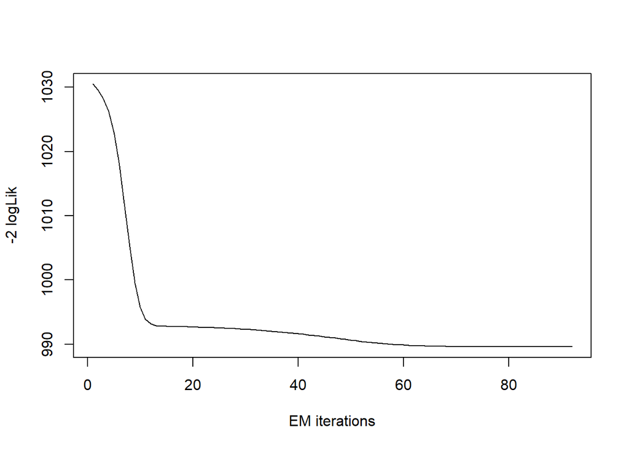

```
## model= 1
```

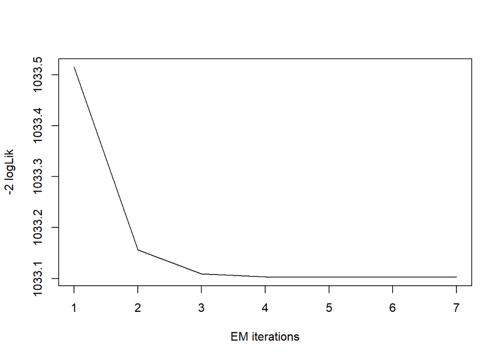

```
## model= 2
```

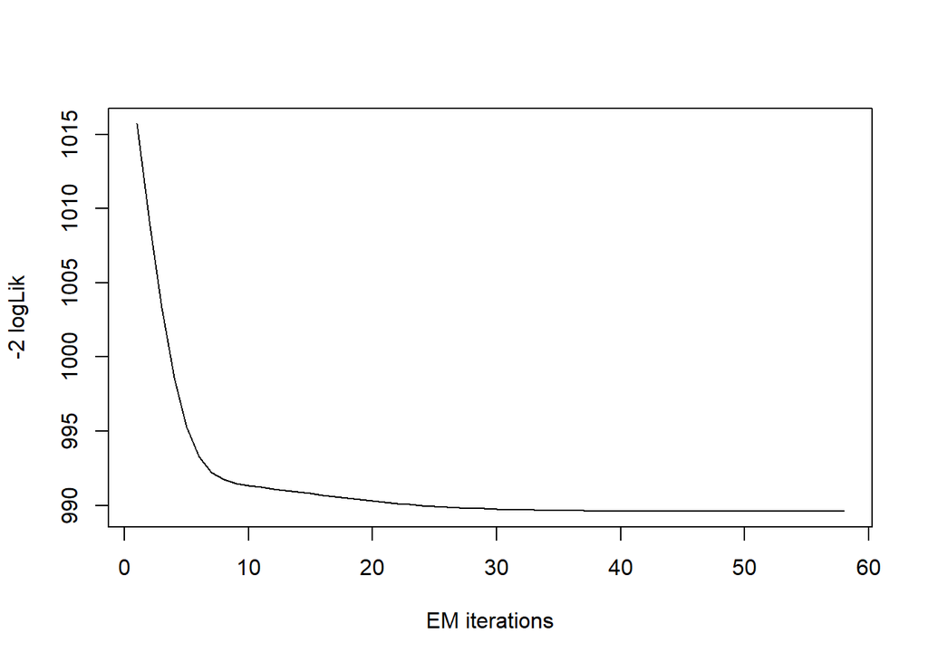

```
## model= 3
```

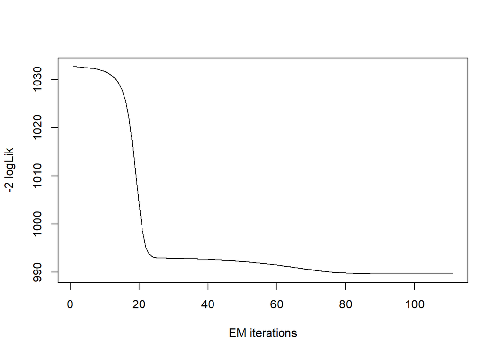

```
## model= 4
```

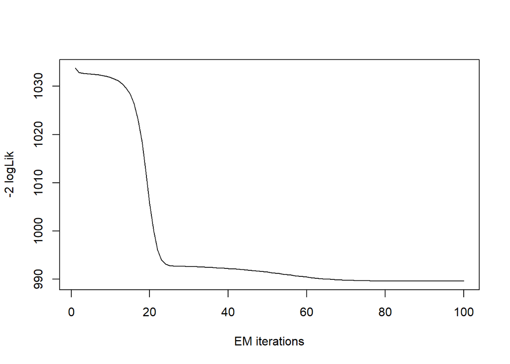

```
## model= 5
```

We now extract the parameter estimates for each gamma component and overlay the two weighted densities on the empirical distribution of Area. The dashed curves correspond to the single components, while the solid curve is the overall mixture.

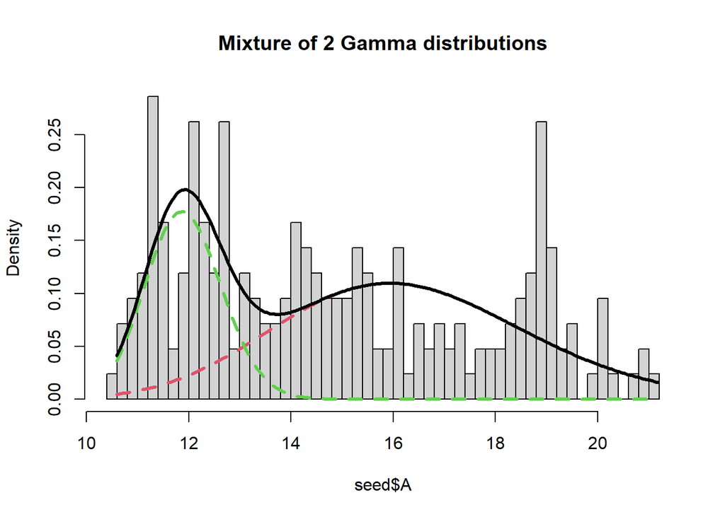

```r
# estimate of mu and sigma in group 1
mu.hat1 <- exp(fit.GA.2[["models"]][[1]][["mu.coefficients"]])   # estimate of mu parameter
sigma.hat1 <- exp(fit.GA.2[["models"]][[1]][["sigma.coefficients"]])

# estimate of mu and sigma in group 2
mu.hat2 <- exp(fit.GA.2[["models"]][[2]][["mu.coefficients"]])
sigma.hat2 <- exp(fit.GA.2[["models"]][[2]][["sigma.coefficients"]])

# histogram + component and mixture densities
hist(seed$A, freq = FALSE, breaks = 50, main = "Mixture of 2 Gamma distributions", xlab = "seed$A")

# weighted density for cluster one
lines(seq(min(seed$A), max(seed$A), length = length(seed$A)),
      fit.GA.2[["prob"]][1] * dGA(seq(min(seed$A), max(seed$A), length = length(seed$A)),
                                  mu = mu.hat1, sigma = sigma.hat1),
      lty = 2, lwd = 3, col = 2)

# weighted density for cluster two
lines(seq(min(seed$A), max(seed$A), length = length(seed$A)),
      fit.GA.2[["prob"]][2] * dGA(seq(min(seed$A), max(seed$A), length = length(seed$A)),
                                  mu = mu.hat2, sigma = sigma.hat2),
      lty = 2, lwd = 3, col = 3)

# total mixture
lines(seq(min(seed$A), max(seed$A), length = length(seed$A)),
      fit.GA.2[["prob"]][1] * dGA(seq(min(seed$A), max(seed$A), length = length(seed$A)),
                                  mu = mu.hat1, sigma = sigma.hat1) +
      fit.GA.2[["prob"]][2] * dGA(seq(min(seed$A), max(seed$A), length = length(seed$A)),
                                  mu = mu.hat2, sigma = sigma.hat2),
      lty = 1, lwd = 3, col = 1)
```

```r
# model summary and log-likelihood (as in the report)
print(fit.GA.2)
```

```
##
## Mixing Family:  c("GA", "GA")
##
## Fitting method: EM algorithm
##
## Call:  gamlssMX(formula = seed$A ~ 1, family = GA, K = 2,      data = NULL)
##
## Mu Coefficients for model: 1
## (Intercept)
##       2.791
## Sigma Coefficients for model: 1
## (Intercept)
##      -1.891
## Mu Coefficients for model: 2
## (Intercept)
##       2.478
## Sigma Coefficients for model: 2
## (Intercept)
##      -2.771
##
## Estimated probabilities: 0.669248 0.330752
##
## Degrees of Freedom for the fit: 5 Residual Deg. of Freedom   205
## Global Deviance:     989.603
##             AIC:     999.603
##             SBC:     1016.34
```

```r
logLik(fit.GA.2)   # df = 5 (1 weight + 2 parameters per gamma)
```

```
## 'log Lik.' -494.8016 (df=5)
```

After convergence, we retrieve the three component parameters and superimpose the weighted densities as before, together with the overall mixture.

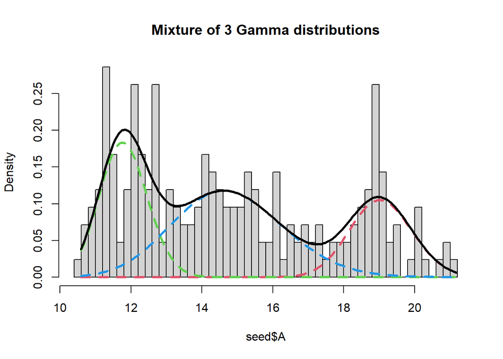

```r
# estimates for groups 1–3
mu.hat1 <- exp(fit.GA.3[["models"]][[1]][["mu.coefficients"]])
sigma.hat1 <- exp(fit.GA.3[["models"]][[1]][["sigma.coefficients"]])

mu.hat2 <- exp(fit.GA.3[["models"]][[2]][["mu.coefficients"]])
sigma.hat2 <- exp(fit.GA.3[["models"]][[2]][["sigma.coefficients"]])

mu.hat3 <- exp(fit.GA.3[["models"]][[3]][["mu.coefficients"]])
sigma.hat3 <- exp(fit.GA.3[["models"]][[3]][["sigma.coefficients"]])

# plot with components and mixture
hist(seed$A, freq = FALSE, breaks = 50, main = "Mixture of 3 Gamma distributions", xlab = "seed$A")

# component 1
lines(seq(min(seed$A), max(seed$A), length = length(seed$A)),
      fit.GA.3[["prob"]][1] * dGA(seq(min(seed$A), max(seed$A), length = length(seed$A)),
                                  mu = mu.hat1, sigma = sigma.hat1),
      lty = 2, lwd = 3, col = 2)

# component 2
lines(seq(min(seed$A), max(seed$A), length = length(seed$A)),
      fit.GA.3[["prob"]][2] * dGA(seq(min(seed$A), max(seed$A), length = length(seed$A)),
                                  mu = mu.hat2, sigma = sigma.hat2),
      lty = 2, lwd = 3, col = 3)

# component 3
lines(seq(min(seed$A), max(seed$A), length = length(seed$A)),
      fit.GA.3[["prob"]][3] * dGA(seq(min(seed$A), max(seed$A), length = length(seed$A)),
                                  mu = mu.hat3, sigma = sigma.hat3),
      lty = 2, lwd = 3, col = 4)

# overall mixture
lines(seq(min(seed$A), max(seed$A), length = length(seed$A)),
      fit.GA.3[["prob"]][1] * dGA(seq(min(seed$A), max(seed$A), length = length(seed$A)),
                                  mu = mu.hat1, sigma = sigma.hat1) +
      fit.GA.3[["prob"]][2] * dGA(seq(min(seed$A), max(seed$A), length = length(seed$A)),
                                  mu = mu.hat2, sigma = sigma.hat2) +
      fit.GA.3[["prob"]][3] * dGA(seq(min(seed$A), max(seed$A), length = length(seed$A)),
                                  mu = mu.hat3, sigma = sigma.hat3),
      lty = 1, lwd = 3, col = 1)
```

```r
# print model summary and logLik
print(fit.GA.3)
```

```
##
## Mixing Family:  c("GA", "GA", "GA")
##
## Fitting method: EM algorithm
##
## Call:  gamlssMX(formula = seed$A ~ 1, family = GA, K = 3,      data = NULL)
##
## Mu Coefficients for model: 1
## (Intercept)
##       2.947
## Sigma Coefficients for model: 1
## (Intercept)
##      -3.075
## Mu Coefficients for model: 2
## (Intercept)
##       2.468
## Sigma Coefficients for model: 2
## (Intercept)
##      -2.861
## Mu Coefficients for model: 3
## (Intercept)
##       2.694
## Sigma Coefficients for model: 3
## (Intercept)
##      -2.248
##
## Estimated probabilities: 0.2314075 0.3098399 0.4587526
##
## Degrees of Freedom for the fit: 8 Residual Deg. of Freedom   202
## Global Deviance:     959.286
##             AIC:     975.286
##             SBC:     1002.06
```

```r
logLik(fit.GA.3)   # df = 8
```

```
## 'log Lik.' -479.6432 (df=8)
```

Now we fit the **Gamma mixture model with four components (K = 4)**.  
The same procedure as before is applied, so only the essential commands are reported here for clarity.

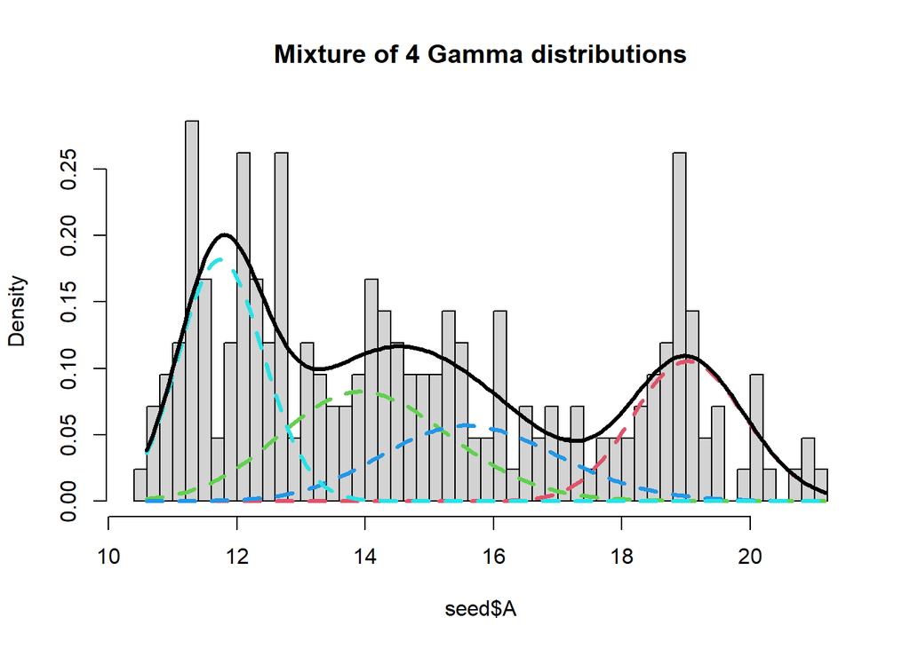

```r
# estimate of mu and sigma in group 1
mu.hat1 <- exp(fit.GA.4[["models"]][[1]][["mu.coefficients"]])   #estimate of mu parameter
sigma.hat1 <- exp(fit.GA.4[["models"]][[1]][["sigma.coefficients"]])

# estimate of mu and sigma in group 2
mu.hat2 <- exp(fit.GA.4[["models"]][[2]][["mu.coefficients"]])
sigma.hat2 <- exp(fit.GA.4[["models"]][[2]][["sigma.coefficients"]])

# estimate of mu and sigma in group 3
mu.hat3 <- exp(fit.GA.4[["models"]][[3]][["mu.coefficients"]])
sigma.hat3 <- exp(fit.GA.4[["models"]][[3]][["sigma.coefficients"]])

# estimate of mu and sigma in group 3
mu.hat4 <- exp(fit.GA.4[["models"]][[4]][["mu.coefficients"]])
sigma.hat4 <- exp(fit.GA.4[["models"]][[4]][["sigma.coefficients"]])

hist(seed$A,freq = FALSE,breaks=50,main="Mixture of 4 Gamma distributions")
lines(seq(min(seed$A),max(seed$A),length=length(seed$A)),fit.GA.4[["prob"]][1]*dGA(seq(min(seed$A),max(seed$A),length=length(seed$A)), mu = mu.hat1, sigma = sigma.hat1),lty=2,lwd=3,col=2) #weighted density for cluster one
lines(seq(min(seed$A),max(seed$A),length=length(seed$A)),fit.GA.4[["prob"]][2]*dGA(seq(min(seed$A),max(seed$A),length=length(seed$A)), mu = mu.hat2, sigma = sigma.hat2),lty=2,lwd=3,col=3) #weighted density for cluster two
lines(seq(min(seed$A),max(seed$A),length=length(seed$A)),fit.GA.4[["prob"]][3]*dGA(seq(min(seed$A),max(seed$A),length=length(seed$A)), mu = mu.hat3, sigma = sigma.hat3),lty=2,lwd=3,col=4) #weighted density for cluster three
lines(seq(min(seed$A),max(seed$A),length=length(seed$A)),fit.GA.4[["prob"]][4]*dGA(seq(min(seed$A),max(seed$A),length=length(seed$A)), mu = mu.hat4, sigma = sigma.hat4),lty=2,lwd=3,col=5) #weighted density for cluster four


lines(seq(min(seed$A),max(seed$A),length=length(seed$A)),
      fit.GA.4[["prob"]][1]*dGA(seq(min(seed$A),max(seed$A),length=length(seed$A)), mu = mu.hat1, sigma = sigma.hat1) +
        fit.GA.4[["prob"]][2]*dGA(seq(min(seed$A),max(seed$A),length=length(seed$A)), mu = mu.hat2, sigma = sigma.hat2)+
        fit.GA.4[["prob"]][3]*dGA(seq(min(seed$A),max(seed$A),length=length(seed$A)), mu = mu.hat3, sigma = sigma.hat3)+
          fit.GA.4[["prob"]][4]*dGA(seq(min(seed$A),max(seed$A),length=length(seed$A)), mu = mu.hat4, sigma = sigma.hat4),
      lty = 1, lwd = 3, col = 1)
```

```r
print(fit.GA.4)
```

```
##
## Mixing Family:  c("GA", "GA", "GA", "GA")
##
## Fitting method: EM algorithm
##
## Call:  gamlssMX(formula = seed$A ~ 1, family = GA, K = 4,      data = NULL)
##
## Mu Coefficients for model: 1
## (Intercept)
##       2.948
## Sigma Coefficients for model: 1
## (Intercept)
##       -3.08
## Mu Coefficients for model: 2
## (Intercept)
##       2.643
## Sigma Coefficients for model: 2
## (Intercept)
##      -2.365
## Mu Coefficients for model: 3
## (Intercept)
##       2.754
## Sigma Coefficients for model: 3
## (Intercept)
##      -2.436
## Mu Coefficients for model: 4
## (Intercept)
##       2.466
## Sigma Coefficients for model: 4
## (Intercept)
##      -2.876
##
## Estimated probabilities: 0.2313441 0.2714742 0.1953294 0.3018523
##
## Degrees of Freedom for the fit: 11 Residual Deg. of Freedom   199
## Global Deviance:     959.168
##             AIC:     981.168
##             SBC:     1017.99
```

```r
logLik(fit.GA.4) #
```

```
## 'log Lik.' -479.5838 (df=11)
```

The plot shows the **fitted mixture of four Gamma components**.  
Dashed curves correspond to each single component, and the solid black line represents the total mixture density.

## Model Comparison and Selection

We now compare the Gamma mixture models with **K = 2, 3, and 4** components using  
the Akaike Information Criterion (**AIC**), the Schwarz Bayesian Criterion (**SBC** or **BIC**),  
and the Log-Likelihood (**LLH**).

Models with smaller AIC and BIC values are preferred, as they achieve a better trade-off between goodness of fit and model complexity.

```r
# Comparison table of information criteria for Gamma mixtures
data.frame(
  row.names = c("Gamma mixture with k=2", "Gamma mixture with k=3", "Gamma mixture with k=4"),
  AIC  = c(fit.GA.2$aic, fit.GA.3$aic, fit.GA.4$aic),
  SBC  = c(fit.GA.2$sbc, fit.GA.3$sbc, fit.GA.4$sbc),
  LLH  = c(as.numeric(logLik(fit.GA.2)), as.numeric(logLik(fit.GA.3)), as.numeric(logLik(fit.GA.4)))
)
```

```
##                             AIC      SBC       LLH
## Gamma mixture with k=2 999.6032 1016.339 -494.8016
## Gamma mixture with k=3 975.2863 1002.063 -479.6432
## Gamma mixture with k=4 981.1677 1017.986 -479.5838
```

Based on the comparison, the **Gamma mixture with K = 3** gives the most suitable fit to the data.  
Although the four-component model achieves a slightly higher log-likelihood, its additional complexity  
does not provide a meaningful improvement and is therefore not justified.

### Weibull Mixture Model (K = 2)

It is possible to fit a **Weibull mixture** model to the same variable,  
since the *Area (A)* values are positive and continuous.  
Here we start with **two components (K = 2)**.

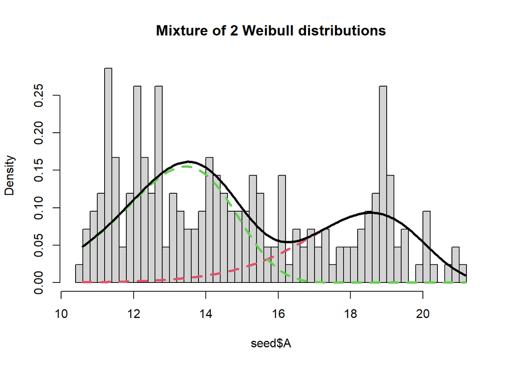

```r
# Estimate of mu and sigma for each group
mu.hat1 <- exp(fit.WE.2[["models"]][[1]][["mu.coefficients"]])
sigma.hat1 <- exp(fit.WE.2[["models"]][[1]][["sigma.coefficients"]])
mu.hat2 <- exp(fit.WE.2[["models"]][[2]][["mu.coefficients"]])
sigma.hat2 <- exp(fit.WE.2[["models"]][[2]][["sigma.coefficients"]])

# Histogram with Weibull mixture
hist(seed$A, freq = FALSE, breaks = 50, main = "Mixture of 2 Weibull distributions", xlab = "seed$A")

# Weighted density for cluster 1
lines(seq(min(seed$A), max(seed$A), length = length(seed$A)),
      fit.WE.2[["prob"]][1] * dWEI(seq(min(seed$A), max(seed$A), length = length(seed$A)),
                                   mu = mu.hat1, sigma = sigma.hat1),
      lty = 2, lwd = 3, col = 2)

# Weighted density for cluster 2
lines(seq(min(seed$A), max(seed$A), length = length(seed$A)),
      fit.WE.2[["prob"]][2] * dWEI(seq(min(seed$A), max(seed$A), length = length(seed$A)),
                                   mu = mu.hat2, sigma = sigma.hat2),
      lty = 2, lwd = 3, col = 3)

# Overall mixture
lines(seq(min(seed$A), max(seed$A), length = length(seed$A)),
      fit.WE.2[["prob"]][1]*dWEI(seq(min(seed$A), max(seed$A), length = length(seed$A)),
                                 mu = mu.hat1, sigma = sigma.hat1) +
      fit.WE.2[["prob"]][2]*dWEI(seq(min(seed$A), max(seed$A), length = length(seed$A)),
                                 mu = mu.hat2, sigma = sigma.hat2),
      lty = 1, lwd = 3, col = 1)
```

```r
# Print model summary
print(fit.WE.2)
```

```
##
## Mixing Family:  c("WEI", "WEI")
##
## Fitting method: EM algorithm
##
## Call:  gamlssMX(formula = seed$A ~ 1, family = WEI, K = 2,      data = NULL)
##
## Mu Coefficients for model: 1
## (Intercept)
##       2.928
## Sigma Coefficients for model: 1
## (Intercept)
##       2.508
## Mu Coefficients for model: 2
## (Intercept)
##       2.611
## Sigma Coefficients for model: 2
## (Intercept)
##       2.225
##
## Estimated probabilities: 0.3844234 0.6155766
##
## Degrees of Freedom for the fit: 5 Residual Deg. of Freedom   205
## Global Deviance:     1004.48
##             AIC:     1014.48
##             SBC:     1031.22
```

```r
logLik(fit.WE.2)
```

```
## 'log Lik.' -502.242 (df=5)
```

The two-component Weibull mixture provides a good fit to the distribution of *Area (A)*.  
Each dashed curve represents one component, while the solid black curve is the overall mixture density.

### Weibull Mixture Model (K = 3)

Now we increase the number of components to **K = 3** in order to test  
whether a higher model complexity leads to a better fit.

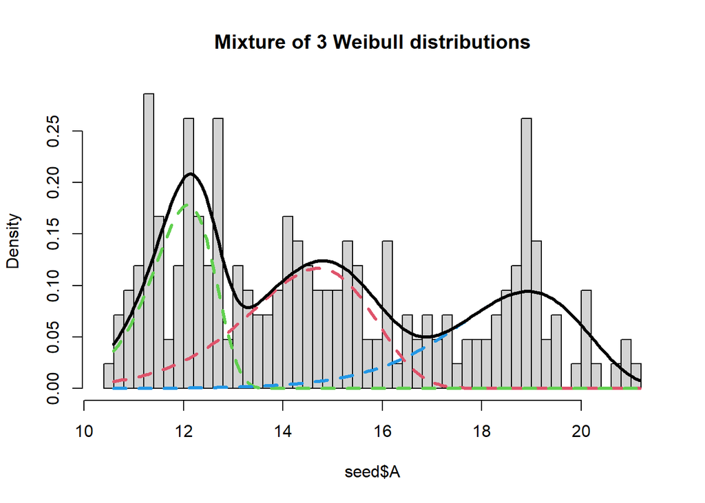

```r
# Extract parameters for each of the three groups
mu.hat1 <- exp(fit.WE.3[["models"]][[1]][["mu.coefficients"]])
sigma.hat1 <- exp(fit.WE.3[["models"]][[1]][["sigma.coefficients"]])
mu.hat2 <- exp(fit.WE.3[["models"]][[2]][["mu.coefficients"]])
sigma.hat2 <- exp(fit.WE.3[["models"]][[2]][["sigma.coefficients"]])
mu.hat3 <- exp(fit.WE.3[["models"]][[3]][["mu.coefficients"]])
sigma.hat3 <- exp(fit.WE.3[["models"]][[3]][["sigma.coefficients"]])

# Histogram with 3-component Weibull mixture
hist(seed$A, freq = FALSE, breaks = 50, main = "Mixture of 3 Weibull distributions", xlab = "seed$A")

# Weighted densities for each component
lines(seq(min(seed$A), max(seed$A), length = length(seed$A)),
      fit.WE.3[["prob"]][1] * dWEI(seq(min(seed$A), max(seed$A), length = length(seed$A)),
                                   mu = mu.hat1, sigma = sigma.hat1),
      lty = 2, lwd = 3, col = 2)

lines(seq(min(seed$A), max(seed$A), length = length(seed$A)),
      fit.WE.3[["prob"]][2] * dWEI(seq(min(seed$A), max(seed$A), length = length(seed$A)),
                                   mu = mu.hat2, sigma = sigma.hat2),
      lty = 2, lwd = 3, col = 3)

lines(seq(min(seed$A), max(seed$A), length = length(seed$A)),
      fit.WE.3[["prob"]][3] * dWEI(seq(min(seed$A), max(seed$A), length = length(seed$A)),
                                   mu = mu.hat3, sigma = sigma.hat3),
      lty = 2, lwd = 3, col = 4)

# Overall mixture
lines(seq(min(seed$A), max(seed$A), length = length(seed$A)),
      fit.WE.3[["prob"]][1]*dWEI(seq(min(seed$A), max(seed$A), length = length(seed$A)),
                                 mu = mu.hat1, sigma = sigma.hat1) +
      fit.WE.3[["prob"]][2]*dWEI(seq(min(seed$A), max(seed$A), length = length(seed$A)),
                                 mu = mu.hat2, sigma = sigma.hat2) +
      fit.WE.3[["prob"]][3]*dWEI(seq(min(seed$A), max(seed$A), length = length(seed$A)),
                                 mu = mu.hat3, sigma = sigma.hat3),
      lty = 1, lwd = 3, col = 1)
```

```r
print(fit.WE.3)
```

```
##
## Mixing Family:  c("WEI", "WEI", "WEI")
##
## Fitting method: EM algorithm
##
## Call:  gamlssMX(formula = seed$A ~ 1, family = WEI, K = 3,      data = NULL)
##
## Mu Coefficients for model: 1
## (Intercept)
##       2.696
## Sigma Coefficients for model: 1
## (Intercept)
##       2.516
## Mu Coefficients for model: 2
## (Intercept)
##       2.495
## Sigma Coefficients for model: 2
## (Intercept)
##        2.98
## Mu Coefficients for model: 3
## (Intercept)
##       2.945
## Sigma Coefficients for model: 3
## (Intercept)
##       2.707
##
## Estimated probabilities: 0.3782498 0.2979003 0.3238499
##
## Degrees of Freedom for the fit: 8 Residual Deg. of Freedom   202
## Global Deviance:     971.105
##             AIC:     987.105
##             SBC:     1013.88
```

```r
logLik(fit.WE.3)
```

```
## 'log Lik.' -485.5527 (df=8)
```

Now we test a **Weibull mixture with four components (K = 4)**.  
The estimation process follows the same procedure used for the previous models.

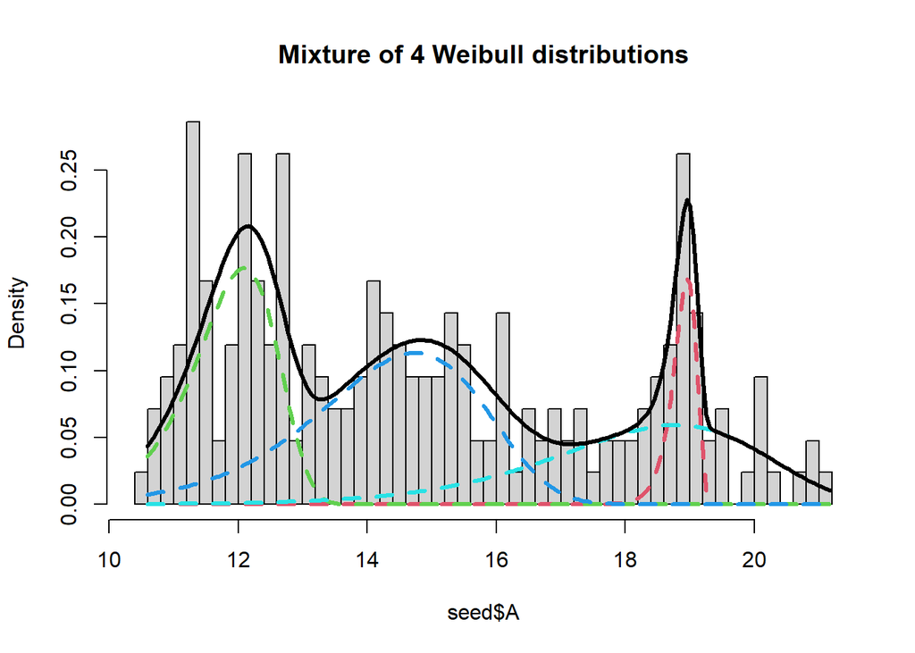

```r
# Extract parameters for each of the four groups
mu.hat1 <- exp(fit.WE.4[["models"]][[1]][["mu.coefficients"]])
sigma.hat1 <- exp(fit.WE.4[["models"]][[1]][["sigma.coefficients"]])
mu.hat2 <- exp(fit.WE.4[["models"]][[2]][["mu.coefficients"]])
sigma.hat2 <- exp(fit.WE.4[["models"]][[2]][["sigma.coefficients"]])
mu.hat3 <- exp(fit.WE.4[["models"]][[3]][["mu.coefficients"]])
sigma.hat3 <- exp(fit.WE.4[["models"]][[3]][["sigma.coefficients"]])
mu.hat4 <- exp(fit.WE.4[["models"]][[4]][["mu.coefficients"]])
sigma.hat4 <- exp(fit.WE.4[["models"]][[4]][["sigma.coefficients"]])

# Histogram with 4-component Weibull mixture
hist(seed$A, freq = FALSE, breaks = 50, main = "Mixture of 4 Weibull distributions", xlab = "seed$A")

# Weighted densities for each component
lines(seq(min(seed$A), max(seed$A), length = length(seed$A)),
      fit.WE.4[["prob"]][1] * dWEI(seq(min(seed$A), max(seed$A), length = length(seed$A)),
                                   mu = mu.hat1, sigma = sigma.hat1),
      lty = 2, lwd = 3, col = 2)

lines(seq(min(seed$A), max(seed$A), length = length(seed$A)),
      fit.WE.4[["prob"]][2] * dWEI(seq(min(seed$A), max(seed$A), length = length(seed$A)),
                                   mu = mu.hat2, sigma = sigma.hat2),
      lty = 2, lwd = 3, col = 3)

lines(seq(min(seed$A), max(seed$A), length = length(seed$A)),
      fit.WE.4[["prob"]][3] * dWEI(seq(min(seed$A), max(seed$A), length = length(seed$A)),
                                   mu = mu.hat3, sigma = sigma.hat3),
      lty = 2, lwd = 3, col = 4)

lines(seq(min(seed$A), max(seed$A), length = length(seed$A)),
      fit.WE.4[["prob"]][4] * dWEI(seq(min(seed$A), max(seed$A), length = length(seed$A)),
                                   mu = mu.hat4, sigma = sigma.hat4),
      lty = 2, lwd = 3, col = 5)

# Overall mixture
lines(seq(min(seed$A), max(seed$A), length = length(seed$A)),
      fit.WE.4[["prob"]][1]*dWEI(seq(min(seed$A), max(seed$A), length = length(seed$A)),
                                 mu = mu.hat1, sigma = sigma.hat1) +
      fit.WE.4[["prob"]][2]*dWEI(seq(min(seed$A), max(seed$A), length = length(seed$A)),
                                 mu = mu.hat2, sigma = sigma.hat2) +
      fit.WE.4[["prob"]][3]*dWEI(seq(min(seed$A), max(seed$A), length = length(seed$A)),
                                 mu = mu.hat3, sigma = sigma.hat3) +
      fit.WE.4[["prob"]][4]*dWEI(seq(min(seed$A), max(seed$A), length = length(seed$A)),
                                 mu = mu.hat4, sigma = sigma.hat4),
      lty = 1, lwd = 3, col = 1)
```

```r
print(fit.WE.4)
```

```
##
## Mixing Family:  c("WEI", "WEI", "WEI", "WEI")
##
## Fitting method: EM algorithm
##
## Call:  gamlssMX(formula = seed$A ~ 1, family = WEI, K = 4,      data = NULL)
##
## Mu Coefficients for model: 1
## (Intercept)
##       2.943
## Sigma Coefficients for model: 1
## (Intercept)
##       4.716
## Mu Coefficients for model: 2
## (Intercept)
##       2.495
## Sigma Coefficients for model: 2
## (Intercept)
##       2.982
## Mu Coefficients for model: 3
## (Intercept)
##       2.698
## Sigma Coefficients for model: 3
## (Intercept)
##       2.484
## Mu Coefficients for model: 4
## (Intercept)
##        2.94
## Sigma Coefficients for model: 4
## (Intercept)
##       2.508
##
## Estimated probabilities: 0.07815877 0.2948822 0.3797081 0.247251
##
## Degrees of Freedom for the fit: 11 Residual Deg. of Freedom   199
## Global Deviance:     959.069
##             AIC:     981.069
##             SBC:     1017.89
```

```r
logLik(fit.WE.4)
```

```
## 'log Lik.' -479.5343 (df=11)
```

The chart above shows the **mixture of four Weibull distributions**.  
Each dashed line represents an individual component, while the solid black line corresponds to the full fitted model.

### Comparison of Weibull Mixture Models

To determine which Weibull mixture provides the best fit,  
we compare the models using **AIC**, **SBC (or BIC)**, and **Log-Likelihood (LLH)** criteria.

```r
data.frame(
  row.names = c("Weibull mixture with k=2",
                "Weibull mixture with k=3",
                "Weibull mixture with k=4"),
  AIC  = c(fit.WE.2$aic, fit.WE.3$aic, fit.WE.4$aic),
  SBC  = c(fit.WE.2$sbc, fit.WE.3$sbc, fit.WE.4$sbc),
  LLH  = c(as.numeric(logLik(fit.WE.2)),
           as.numeric(logLik(fit.WE.3)),
           as.numeric(logLik(fit.WE.4)))
)
```

```
##                                AIC      SBC       LLH
## Weibull mixture with k=2 1014.4840 1031.220 -502.2420
## Weibull mixture with k=3  987.1053 1013.882 -485.5527
## Weibull mixture with k=4  981.0687 1017.887 -479.5343
```

Based on the comparison table, the **Weibull mixture with K = 4 components**  
appears to provide the best overall fit according to two of the three model selection criteria.  
This configuration captures the main distributional patterns of the data more effectively  
while maintaining a reasonable model complexity.

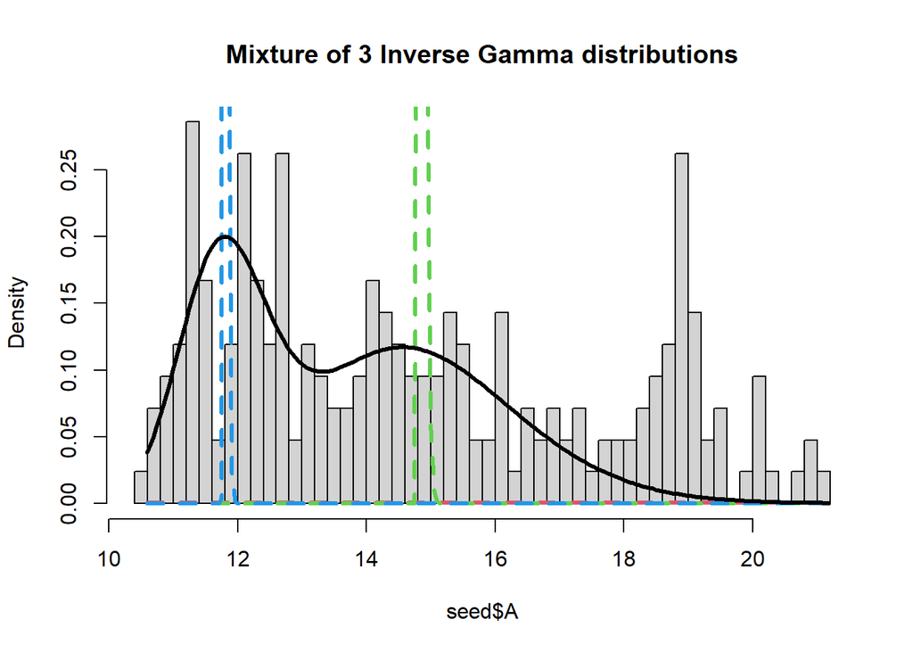

```r
# estimate of mu and sigma in group 2
mu.hat2 <- exp(fit.IG.3[["models"]][[2]][["mu.coefficients"]])
sigma.hat2 <- exp(fit.IG.3[["models"]][[2]][["sigma.coefficients"]])

mu.hat3 <- exp(fit.IG.3[["models"]][[3]][["mu.coefficients"]])
sigma.hat3 <- exp(fit.IG.3[["models"]][[3]][["sigma.coefficients"]])

hist(seed$A, freq = FALSE, breaks = 50, main = "Mixture of 3 Inverse Gamma distributions")
lines(seq(min(seed$A), max(seed$A), length = length(seed$A)),
      fit.IG.3[["prob"]][1] * dRG(seq(min(seed$A), max(seed$A), length = length(seed$A)),
                                  mu = mu.hat1, sigma = sigma.hat1),
      lty = 2, lwd = 3, col = 2) # weighted density for cluster one

lines(seq(min(seed$A), max(seed$A), length = length(seed$A)),
      fit.IG.3[["prob"]][2] * dRG(seq(min(seed$A), max(seed$A), length = length(seed$A)),
                                  mu = mu.hat2, sigma = sigma.hat2),
      lty = 2, lwd = 3, col = 3) # weighted density for cluster two

lines(seq(min(seed$A), max(seed$A), length = length(seed$A)),
      fit.IG.3[["prob"]][3] * dRG(seq(min(seed$A), max(seed$A), length = length(seed$A)),
                                  mu = mu.hat3, sigma = sigma.hat3),
      lty = 2, lwd = 3, col = 4) # weighted density for cluster two

lines(seq(min(seed$A), max(seed$A), length = length(seed$A)),
      fit.IG.3[["prob"]][1]*dIG(seq(min(seed$A), max(seed$A), length = length(seed$A)),
                                mu = mu.hat1, sigma = sigma.hat1) +
        fit.IG.3[["prob"]][2]*dIG(seq(min(seed$A), max(seed$A), length = length(seed$A)),
                                  mu = mu.hat2, sigma = sigma.hat2) +
        fit.IG.3[["prob"]][3]*dIG(seq(min(seed$A), max(seed$A), length = length(seed$A)),
                                  mu = mu.hat3, sigma = sigma.hat3),
      lty = 1, lwd = 3, col = 1)
```

```r
print(fit.IG.3)
```

```
##
## Mixing Family:  c("IG", "IG", "IG")
##
## Fitting method: EM algorithm
##
## Call:  gamlssMX(formula = seed$A ~ 1, family = IG, K = 3,      data = NULL)
##
## Mu Coefficients for model: 1
## (Intercept)
##       2.949
## Sigma Coefficients for model: 1
## (Intercept)
##      -4.574
## Mu Coefficients for model: 2
## (Intercept)
##       2.697
## Sigma Coefficients for model: 2
## (Intercept)
##      -3.569
## Mu Coefficients for model: 3
## (Intercept)
##       2.468
## Sigma Coefficients for model: 3
## (Intercept)
##      -4.093
##
## Estimated probabilities: 0.2244496 0.4659244 0.3096259
##
## Degrees of Freedom for the fit: 8 Residual Deg. of Freedom   202
## Global Deviance:     958.728
##             AIC:     974.728
##             SBC:     1001.51
```

```r
logLik(fit.IG.3)
```

```
## 'log Lik.' -479.3641 (df=8)
```

We now attempt to increase the number of mixture components to **K = 4**,  
to assess whether this provides a significantly better fit.

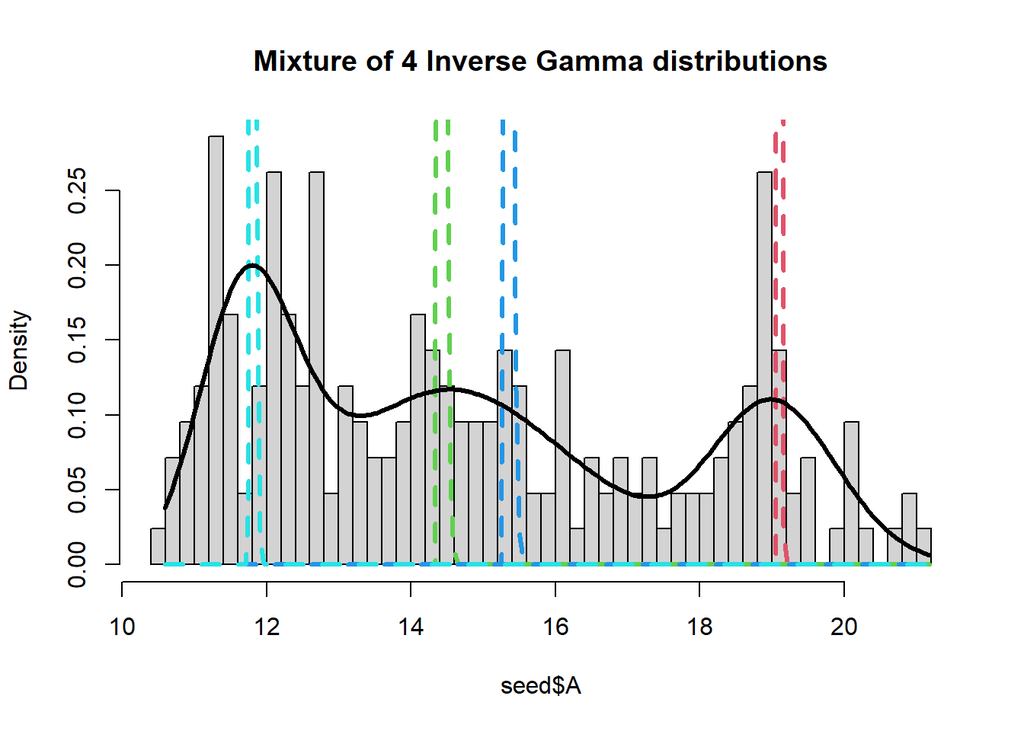

```r
# estimate of mu and sigma in group 1
mu.hat1 <- exp(fit.IG.4[["models"]][[1]][["mu.coefficients"]])
sigma.hat1 <- exp(fit.IG.4[["models"]][[1]][["sigma.coefficients"]])

# estimate of mu and sigma in group 2
mu.hat2 <- exp(fit.IG.4[["models"]][[2]][["mu.coefficients"]])
sigma.hat2 <- exp(fit.IG.4[["models"]][[2]][["sigma.coefficients"]])

# estimate of mu and sigma in group 3
mu.hat3 <- exp(fit.IG.4[["models"]][[3]][["mu.coefficients"]])
sigma.hat3 <- exp(fit.IG.4[["models"]][[3]][["sigma.coefficients"]])

# estimate of mu and sigma in group 4
mu.hat4 <- exp(fit.IG.4[["models"]][[4]][["mu.coefficients"]])
sigma.hat4 <- exp(fit.IG.4[["models"]][[4]][["sigma.coefficients"]])

hist(seed$A, freq = FALSE, breaks = 50, main = "Mixture of 4 Inverse Gamma distributions")
lines(seq(min(seed$A), max(seed$A), length = length(seed$A)),
      fit.IG.4[["prob"]][1] * dRG(seq(min(seed$A), max(seed$A), length = length(seed$A)),
                                  mu = mu.hat1, sigma = sigma.hat1),
      lty = 2, lwd = 3, col = 2) # weighted density for cluster one

lines(seq(min(seed$A), max(seed$A), length = length(seed$A)),
      fit.IG.4[["prob"]][2] * dRG(seq(min(seed$A), max(seed$A), length = length(seed$A)),
                                  mu = mu.hat2, sigma = sigma.hat2),
      lty = 2, lwd = 3, col = 3) # weighted density for cluster two

lines(seq(min(seed$A), max(seed$A), length = length(seed$A)),
      fit.IG.4[["prob"]][3] * dRG(seq(min(seed$A), max(seed$A), length = length(seed$A)),
                                  mu = mu.hat3, sigma = sigma.hat3),
      lty = 2, lwd = 3, col = 4) # weighted density for cluster three

lines(seq(min(seed$A), max(seed$A), length = length(seed$A)),
      fit.IG.4[["prob"]][4] * dRG(seq(min(seed$A), max(seed$A), length = length(seed$A)),
                                  mu = mu.hat4, sigma = sigma.hat4),
      lty = 2, lwd = 3, col = 5) # weighted density for cluster four

lines(seq(min(seed$A), max(seed$A), length = length(seed$A)),
      fit.IG.4[["prob"]][1]*dIG(seq(min(seed$A), max(seed$A), length = length(seed$A)),
                                mu = mu.hat1, sigma = sigma.hat1) +
        fit.IG.4[["prob"]][2]*dIG(seq(min(seed$A), max(seed$A), length = length(seed$A)),
                                  mu = mu.hat2, sigma = sigma.hat2) +
        fit.IG.4[["prob"]][3]*dIG(seq(min(seed$A), max(seed$A), length = length(seed$A)),
                                  mu = mu.hat3, sigma = sigma.hat3) +
        fit.IG.4[["prob"]][4]*dIG(seq(min(seed$A), max(seed$A), length = length(seed$A)),
                                  mu = mu.hat4, sigma = sigma.hat4),
      lty = 1, lwd = 3, col = 1)
```

```r
print(fit.IG.4)
```

```
##
## Mixing Family:  c("IG", "IG", "IG", "IG")
##
## Fitting method: EM algorithm
##
## Call:  gamlssMX(formula = seed$A ~ 1, family = IG, K = 4,      data = NULL)
##
## Mu Coefficients for model: 1
## (Intercept)
##       2.949
## Sigma Coefficients for model: 1
## (Intercept)
##      -4.579
## Mu Coefficients for model: 2
## (Intercept)
##       2.668
## Sigma Coefficients for model: 2
## (Intercept)
##      -3.606
## Mu Coefficients for model: 3
## (Intercept)
##        2.73
## Sigma Coefficients for model: 3
## (Intercept)
##        -3.6
## Mu Coefficients for model: 4
## (Intercept)
##       2.467
## Sigma Coefficients for model: 4
## (Intercept)
##      -4.097
##
## Estimated probabilities: 0.2224909 0.2473748 0.2218784 0.308256
##
## Degrees of Freedom for the fit: 11 Residual Deg. of Freedom   199
## Global Deviance:     958.72
##             AIC:     980.72
##             SBC:     1017.54
```

```r
logLik(fit.IG.4)
```

```
## 'log Lik.' -479.3599 (df=11)
```

### Univariate Analysis for K = 1

Now we perform the **univariate analysis** by fitting several single-component models (*K = 1*)  
using different continuous distributions.  
This allows us to identify which distribution best describes the *Area (A)* variable among  
the family of real positive continuous models.

### Fitted Distributions Visualization

Below we show the fitted density curve (in red) over the histogram of the data for each distribution.

```r
set.seed(1)
par(mfrow=c(2,4)) # Questo comando imposta il layout per 2 righe e 4 colonne, permettendo di visualizzare 8 grafici contemporaneamente.

fit.EXP <- histDist(seed$A, family=EXP, nbins = 30, main="Exponential distribution") #best exponential model with respect to the histogram to fit the data
fit.EXP$df.fit # number of parameters
```

```
## [1] 1
```

```r
fitted(fit.EXP, "mu")[1] # ML estimated parameter
```

```
## [1] 14.84752
```

```r
logLik(fit.EXP)
```

```
## 'log Lik.' -776.545 (df=1)
```

```r
AIC(fit.EXP) # AIC (to be minimized)
```

```
## [1] 1555.09
```

```r
fit.EXP$sbc  # BIC (to be minimized)
```

```
## [1] 1558.437
```

```r
fit.GA <- histDist(seed$A, family=GA, nbins = 30, main="Gamma distribution")
fit.GA$df.fit # number of parameters
```

```
## [1] 2
```

```r
fitted(fit.GA, "mu")[1] # ML estimated first parameter
```

```
## [1] 14.84752
```

```r
fitted(fit.GA, "sigma")[1] # ML estimated second parameter
```

```
## [1] 0.1931169
```

```r
logLik(fit.GA)
```

```
## 'log Lik.' -516.5516 (df=2)
```

```r
AIC(fit.GA) # AIC (to be minimized)
```

```
## [1] 1037.103
```

```r
fit.GA$sbc  # BIC (to be minimized)
```

```
## [1] 1043.797
```

```r
fit.IG <- histDist(seed$A, family=IG, nbins = 30, main="Inverse Gaussian distribution") #this is not good
fit.IG$df.fit
```

```
## [1] 2
```

```r
fitted(fit.IG, "mu")[1] # ML estimated first parameter
```

```
## [1] 14.84752
```

```r
fitted(fit.IG, "sigma")[1] # ML estimated second parameter
```

```
## [1] 0.05045369
```

```r
logLik(fit.IG)
```

```
## 'log Lik.' -514.6783 (df=2)
```

```r
AIC(fit.IG) # AIC (to be minimized)
```

```
## [1] 1033.357
```

```r
fit.IG$sbc  # BIC (to be minimized)
```

```
## [1] 1040.051
```

```r
fit.LOGNO <- histDist(seed$A, family=LOGNO, nbins = 30, main="Log-Normal distribution") #better than the previous one but still not optimal
fit.LOGNO$df.fit
```

```
## [1] 2
```

```r
fitted(fit.LOGNO, "mu")[1] # ML estimated first parameter
```

```
## [1] 2.67907
```

```r
fitted(fit.LOGNO, "sigma")[1] # ML estimated second parameter
```

```
## [1] 0.192973
```

```r
logLik(fit.LOGNO)
```

```
## 'log Lik.' -515.089 (df=2)
```

```r
AIC(fit.LOGNO) # AIC (to be minimized)
```

```
## [1] 1034.178
```

```r
fit.LOGNO$sbc  # BIC (to be minimized)
```

```
## [1] 1040.872
```

```r
fit.WEI <- histDist(seed$A, family=WEI, nbins = 30, main="Weibull distribution") # seems to be the best one till now
fit.WEI$df.fit
```

```
## [1] 2
```

```r
fitted(fit.WEI, "mu")[1] # ML estimated first parameter
```

```
## [1] 16.06708
```

```r
fitted(fit.WEI, "sigma")[1] # ML estimated second parameter
```

```
## [1] 5.509844
```

```r
logLik(fit.WEI)
```

```
## 'log Lik.' -527.2807 (df=2)
```

```r
AIC(fit.WEI) # AIC (to be minimized)
```

```
## [1] 1058.561
```

```r
fit.WEI$sbc  # BIC (to be minimized)
```

```
## [1] 1065.256
```

```r
fit.LO <- histDist(seed$A, family=LO, nbins = 30, main="Logistic distribution") # seems to be the best one till now
fit.LO$df.fit
```

```
## [1] 2
```

```r
fitted(fit.LO, "mu")[1] # ML estimated first parameter
```

```
## [1] 14.66503
```

```r
fitted(fit.LO, "sigma")[1] # ML estimated second parameter
```

```
## [1] 1.748387
```

```r
logLik(fit.LO)
```

```
## 'log Lik.' -530.289 (df=2)
```

```r
AIC(fit.LO) # AIC (to be minimized)
```

```
## [1] 1064.578
```

```r
fit.LO$sbc  # BIC (to be minimized)
```

```
## [1] 1071.272
```

```r
fit.ST5 <- histDist(seed$A, family=ST5, nbins = 30, main="Skew t type 5") # seems to be the best one till now
fit.ST5$df.fit # corretto riferimento a fit.ST5
```

```
## [1] 4
```

```r
fitted(fit.ST5, "mu")[1] # ML estimated first parameter
```

```
## [1] 3.19903
```

```r
fitted(fit.ST5, "sigma")[1] # ML estimated second parameter
```

```
## [1] 0.0001860535
```

```r
logLik(fit.ST5)
```

```
## 'log Lik.' -513.2098 (df=4)
```

```r
AIC(fit.ST5) # AIC (to be minimized)
```

```
## [1] 1034.42
```

```r
fit.ST5$sbc  # BIC (to be minimized)
```

```
## [1] 1047.808
```

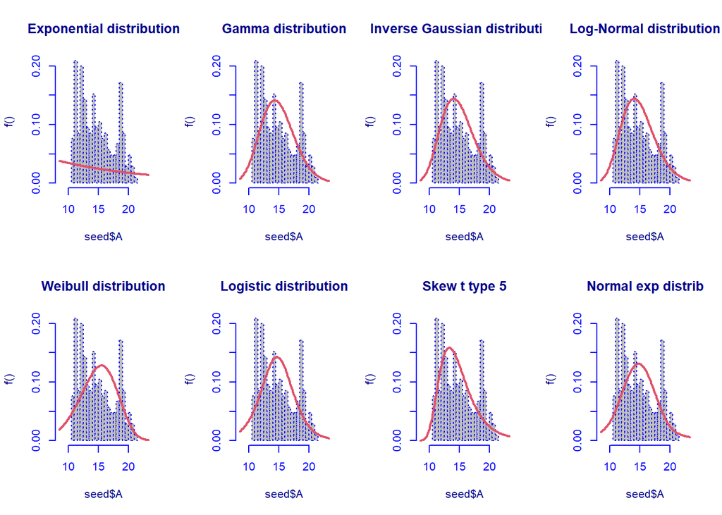

```r
fit.NET <- histDist(seed$A, family=NET, nbins = 30, main="Normal exp distrib") # seems to be the best one till now
```

```r
fit.NET$df.fit # corretto riferimento a fit.NET
```

```
## [1] 2
```

```r
fitted(fit.NET, "mu")[1] # ML estimated first parameter
```

```
## [1] 14.7548
```

```r
fitted(fit.NET, "sigma")[1] # ML estimated second parameter
```

```
## [1] 2.812783
```

```r
logLik(fit.NET)
```

```
## 'log Lik.' -536.6121 (df=2)
```

```r
AIC(fit.NET) # AIC (to be minimized)
```

```
## [1] 1077.224
```

```r
fit.NET$sbc  # BIC (to be minimized)
```

[output not shown]

### Model Comparison Summary

A summary table of the **BIC**, **AIC**, and **Log-Likelihood** values for each fitted model is reported below.

```
##           df      AIC
## fit.IG     2 1033.357
## fit.LOGNO  2 1034.178
## fit.ST5    4 1034.420
## fit.GA     2 1037.103
## fit.WEI    2 1058.561
## fit.LO     2 1064.578
## fit.NET    2 1077.224
## fit.EXP    1 1555.090
```

```
##       df    LogLik      AIC      BIC
## EXP    1 -776.5450 1555.090 1558.437
## GA     2 -516.5516 1037.103 1043.797
## IG     2 -514.6783 1033.357 1040.051
## LOGNO  2 -515.0890 1034.178 1040.872
## WEI    2 -527.2807 1058.561 1065.256
## LO     2 -530.2890 1064.578 1071.272
## ST5    4 -513.2098 1034.420 1047.808
## NET    2 -536.6121 1077.224 1094.613
```

### Model Interpretation

Among the fitted models belonging to the family of positive continuous distributions,  
according to the **Akaike Information Criterion (AIC)** and the **Bayesian Information Criterion (BIC)**,  
the **Inverse Gaussian model (IG)** provides the best fit to the *Area* variable.

However, the **Log-Likelihood** is slightly improved under the **Skew-t type 5 (ST5)** model.  
This improvement is marginal and comes at the cost of two additional degrees of freedom.  
Therefore, the **Inverse Gaussian distribution** is selected as the most suitable univariate model.

### Descriptive Analysis of the Remaining Variables

Now we analyze the remaining continuous variables of the dataset:  
**Perimeter (P)**, **Compactness (C)**, **Length of kernel (LK)**, **Width of kernel (WK)**,  
**Asymmetry coefficient (A_Coef)**, and **Length of kernel groove (LKG)**.

```r
summary(seed[2:5])
```

```
##        P               C                LK              WK
##  Min.   :12.41   Min.   :0.8081   Min.   :4.899   Min.   :2.630
##  1st Qu.:13.45   1st Qu.:0.8569   1st Qu.:5.262   1st Qu.:2.944
##  Median :14.32   Median :0.8734   Median :5.524   Median :3.237
##  Mean   :14.56   Mean   :0.8710   Mean   :5.629   Mean   :3.259
##  3rd Qu.:15.71   3rd Qu.:0.8878   3rd Qu.:5.980   3rd Qu.:3.562
##  Max.   :17.25   Max.   :0.9183   Max.   :6.675   Max.   :4.033
```

```r
summary(seed[6:7])
```

```
##      A_Coef            LKG
##  Min.   :0.7651   Min.   :4.519
##  1st Qu.:2.5615   1st Qu.:5.045
##  Median :3.5990   Median :5.223
##  Mean   :3.7002   Mean   :5.408
##  3rd Qu.:4.7687   3rd Qu.:5.877
##  Max.   :8.4560   Max.   :6.550
```

Except for the *asymmetry coefficient*, no strong outliers are observed among these variables.

### Boxplots of the Main Variables

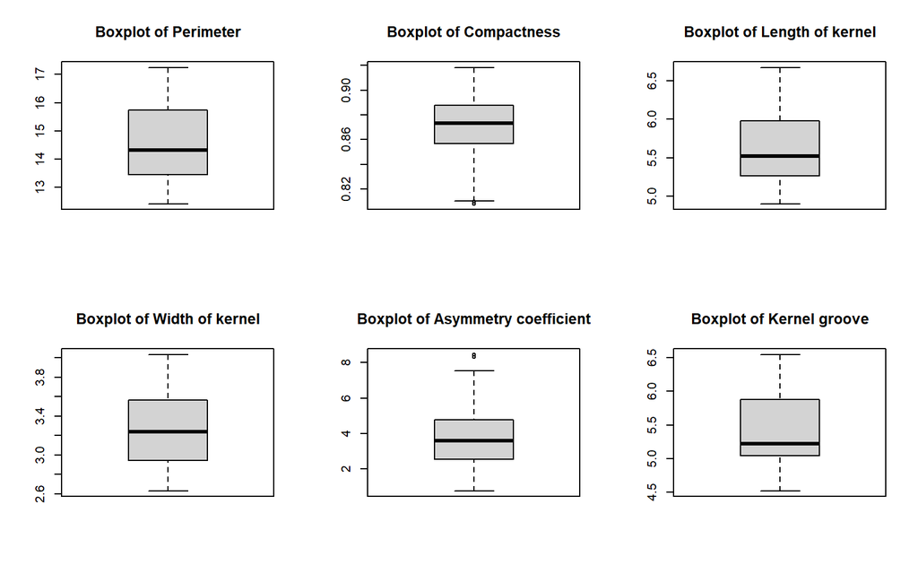

```r
par(mfrow=c(2,3))
boxplot(seed$P, main="Boxplot of Perimeter")
boxplot(seed$C, main="Boxplot of Compactness")
boxplot(seed$LK, main="Boxplot of Length of kernel")
boxplot(seed$WK, main="Boxplot of Width of kernel")
boxplot(seed$A_Coef, main="Boxplot of Asymmetry coefficient")
boxplot(seed$LKG, main="Boxplot of Kernel groove")
```

The boxplots confirm that most variables are symmetrically distributed,  
while the asymmetry coefficient shows a few observations that may be considered outliers.

### Study of Asymmetry Coefficient (A_Coef)

We now focus on the variable **Asymmetry coefficient (A_Coef)** to explore its distribution  
and evaluate which mixture model best represents its shape.

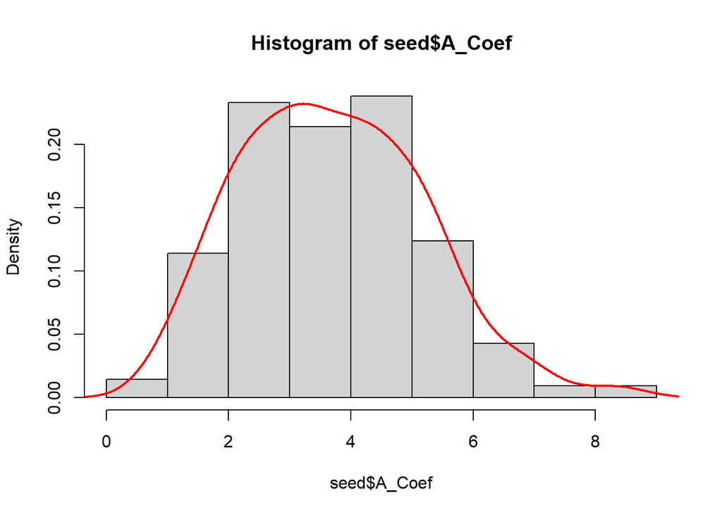

```r
# Histogram and kernel density
hist(seed$A_Coef, freq=FALSE, main="Histogram of seed$A_Coef")
lines(density(seed$A_Coef), col="red", lwd=2)
```

### Fitting a Gamma Mixture with K = 2

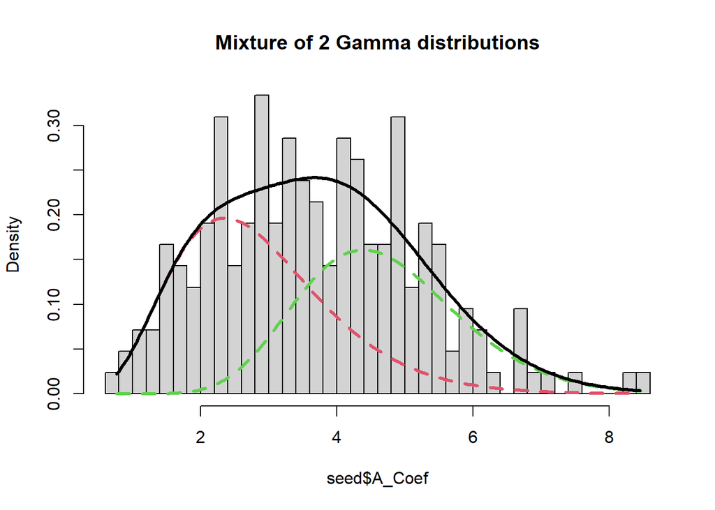

```
##
## Mixing Family:  c("GA", "GA")
##
## Fitting method: EM algorithm
##
## Call:  gamlssMX(formula = seed$A_Coef ~ 1, family = GA, K = 2,
##     data = NULL)
##
## Mu Coefficients for model: 1
## (Intercept)
##       1.042
## Sigma Coefficients for model: 1
## (Intercept)
##     -0.8859
## Mu Coefficients for model: 2
## (Intercept)
##       1.545
## Sigma Coefficients for model: 2
## (Intercept)
##      -1.371
##
## Estimated probabilities: 0.5330378 0.4669622
##
## Degrees of Freedom for the fit: 5 Residual Deg. of Freedom   205
## Global Deviance:     753.532
##             AIC:     763.532
##             SBC:     780.268
```

```
## 'log Lik.' -376.766 (df=5)
```

```
## [1] 0.5330378 0.4669622
```

### Fitting a Gamma Mixture with K = 3

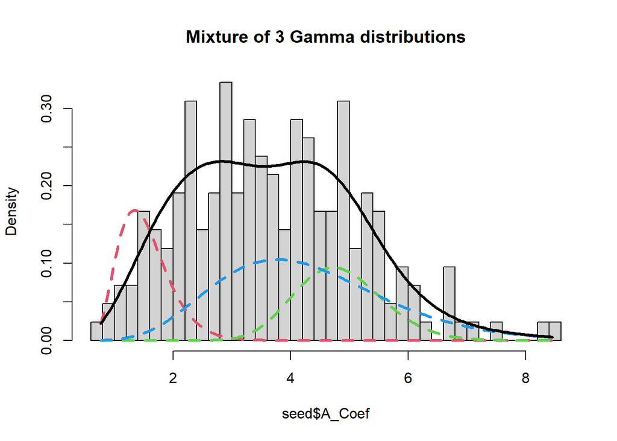

```
##
## Mixing Family:  c("GA", "GA", "GA")
##
## Fitting method: EM algorithm
##
## Call:  gamlssMX(formula = seed$A_Coef ~ 1, family = GA, K = 3,
##     data = NULL)
##
## Mu Coefficients for model: 1
## (Intercept)
##       1.025
## Sigma Coefficients for model: 1
## (Intercept)
##     -0.8709
## Mu Coefficients for model: 2
## (Intercept)
##       1.577
## Sigma Coefficients for model: 2
## (Intercept)
##       -1.86
## Mu Coefficients for model: 3
## (Intercept)
##       1.455
## Sigma Coefficients for model: 3
## (Intercept)
##      -1.065
##
## Estimated probabilities: 0.4556684 0.1764964 0.3678351
##
## Degrees of Freedom for the fit: 8 Residual Deg. of Freedom   202
## Global Deviance:     752.741
##             AIC:     768.741
##             SBC:     795.518
```

```
## 'log Lik.' -376.3706 (df=8)
```

### Fitting a Weibull Mixture with K = 2

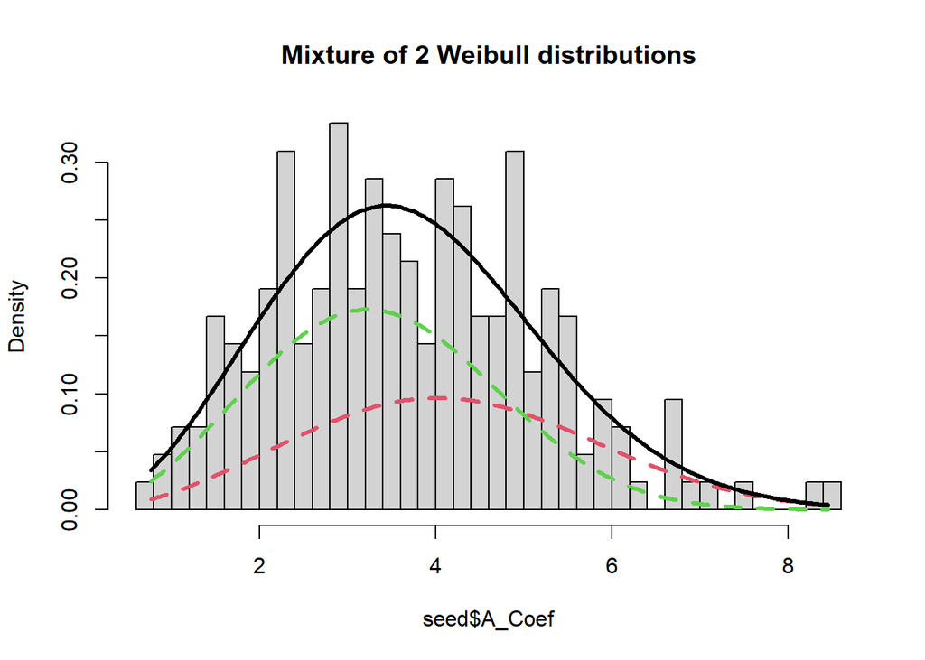

```
##
## Mixing Family:  c("WEI", "WEI")
##
## Fitting method: EM algorithm
##
## Call:  gamlssMX(formula = seed$A_Coef ~ 1, family = WEI, K = 2,
##     data = NULL)
##
## Mu Coefficients for model: 1
## (Intercept)
##       1.548
## Sigma Coefficients for model: 1
## (Intercept)
##       1.033
## Mu Coefficients for model: 2
## (Intercept)
##       1.331
## Sigma Coefficients for model: 2
## (Intercept)
##       1.026
##
## Estimated probabilities: 0.408219 0.591781
##
## Degrees of Freedom for the fit: 5 Residual Deg. of Freedom   205
## Global Deviance:     756.182
##             AIC:     766.182
##             SBC:     782.917
```

```
## 'log Lik.' -378.0909 (df=5)
```

### Weibull Mixture Model (K = 3)

Finally, we fit a **Weibull mixture with three components (K = 3)** to verify whether  
adding another subgroup improves the model’s fit for the *Asymmetry coefficient (A_Coef)*.

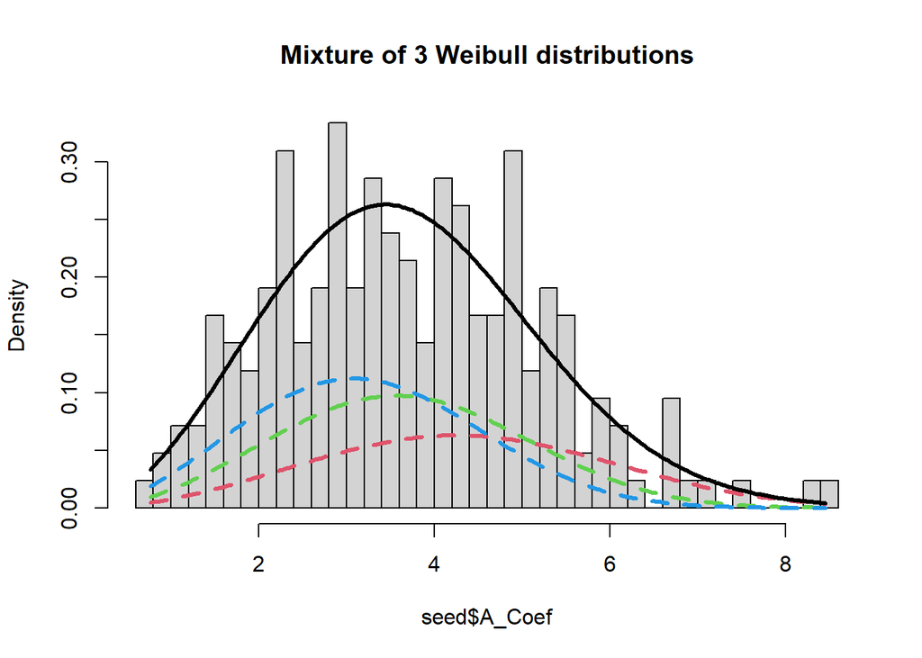

```
##
## Mixing Family:  c("WEI", "WEI", "WEI")
##
## Fitting method: EM algorithm
##
## Call:  gamlssMX(formula = seed$A_Coef ~ 1, family = WEI, K = 3,
##     data = NULL)
##
## Mu Coefficients for model: 1
## (Intercept)
##       1.594
## Sigma Coefficients for model: 1
## (Intercept)
##       1.058
## Mu Coefficients for model: 2
## (Intercept)
##       1.415
## Sigma Coefficients for model: 2
## (Intercept)
##        1.07
## Mu Coefficients for model: 3
## (Intercept)
##       1.292
## Sigma Coefficients for model: 3
## (Intercept)
##       1.003
##
## Estimated probabilities: 0.2733469 0.3494861 0.377167
##
## Degrees of Freedom for the fit: 8 Residual Deg. of Freedom   202
## Global Deviance:     756.142
##             AIC:     772.142
##             SBC:     798.919
```

```
## 'log Lik.' -378.0711 (df=8)
```

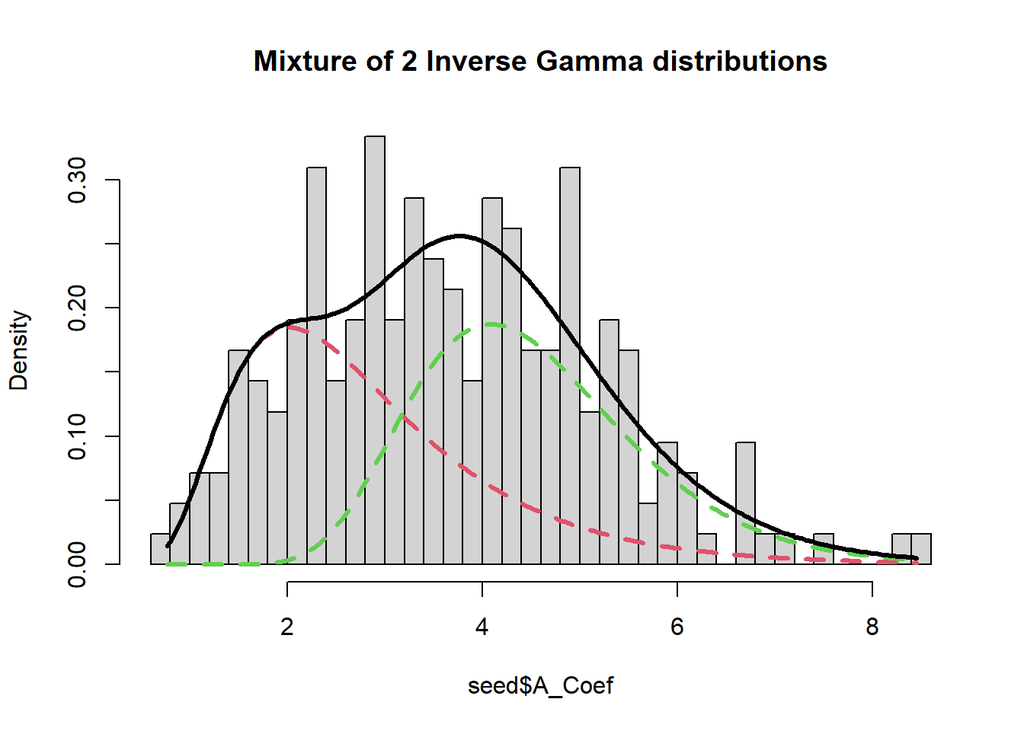

```
##
## Mixing Family:  c("IG", "IG")
##
## Fitting method: EM algorithm
##
## Call:  gamlssMX(formula = seed$A_Coef ~ 1, family = IG, K = 2,
##     data = NULL)
##
## Mu Coefficients for model: 1
## (Intercept)
##       1.039
## Sigma Coefficients for model: 1
## (Intercept)
##      -1.255
## Mu Coefficients for model: 2
## (Intercept)
##       1.509
## Sigma Coefficients for model: 2
## (Intercept)
##      -2.096
##
## Estimated probabilities: 0.4853452 0.5146548
##
## Degrees of Freedom for the fit: 5 Residual Deg. of Freedom   205
## Global Deviance:     755.33
##             AIC:     765.33
##             SBC:     782.066
```

```
## 'log Lik.' -377.6652 (df=5)
```

[output not shown]

### Univariate Analysis for A_Coef with K = 1

Now we apply the **univariate analysis** to the variable *A_Coef* using several single-component models (K = 1).  
This step helps identify which distribution provides the best fit to the data.

### Fitted Distributions Visualization

The following plots show the histogram of *A_Coef* with the fitted density (in red) for each distribution.

```
## [1] 1
```

```
## [1] 3.700201
```

```
## 'log Lik.' -484.7613 (df=1)
```

```
## [1] 971.5226
```

```
## [1] 974.8697
```

```
## [1] 2
```

```
## [1] 3.700201
```

```
## [1] 0.4256079
```

```
## 'log Lik.' -380.0827 (df=2)
```

```
## [1] 764.1653
```

```
## [1] 770.8596
```

```
## [1] 2
```

```
## [1] 3.70022
```

```
## [1] 0.2498304
```

```
## 'log Lik.' -389.4664 (df=2)
```

```
## [1] 782.9328
```

```
## [1] 789.627
```

```
## [1] 2
```

```
## [1] 1.215092
```

```
## [1] 0.4548616
```

```
## 'log Lik.' -387.7155 (df=2)
```

```
## [1] 779.431
```

```
## [1] 786.1252
```

```
## [1] 2
```

```
## [1] 4.167869
```

```
## [1] 2.65879
```

```
## 'log Lik.' -378.3609 (df=2)
```

```
## [1] 760.7218
```

```
## [1] 767.416
```

```
## [1] 2
```

```
## [1] 3.649628
```

```
## [1] 0.8681267
```

```
## 'log Lik.' -386.3389 (df=2)
```

```
## [1] 776.6778
```

```
## [1] 783.3721
```

```
## [1] 2
```

```
## [1] 3.649628
```

```
## [1] 0.8681267
```

```
## 'log Lik.' -386.3389 (df=2)
```

```
## [1] 776.6778
```

```
## [1] 783.3721
```

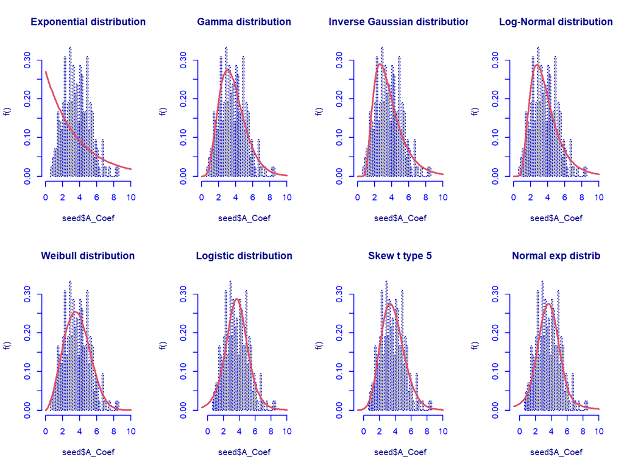

```
## [1] 2
```

```
## [1] 3.649628
```

```
## [1] 0.8681267
```

```
## 'log Lik.' -386.3389 (df=2)
```

```
## [1] 776.6778
```

```
## [1] 783.3721
```

### Model Comparison: AIC, BIC and Log-Likelihood

We summarize the model fit statistics — **degrees of freedom (df)**, **log-likelihood**, **AIC**, and **BIC** —  
for all fitted univariate distributions.

```
##           df      AIC
## fit.WEI    2 760.7218
## fit.GA     2 764.1653
## fit.ST5    4 767.2712
## fit.LO     2 776.6778
## fit.LOGNO  2 779.4310
## fit.IG     2 782.9328
## fit.NET    2 787.8161
## fit.EXP    1 971.5226
```

```
##       df    LogLik      AIC      BIC
## EXP    1 -484.7613 971.5226 974.8697
## GA     2 -380.0827 764.1653 770.8596
## IG     2 -389.4664 782.9328 789.6270
## LOGNO  2 -387.7155 779.4310 786.1252
## WEI    2 -378.3609 760.7218 767.4160
## LO     2 -386.3389 776.6778 783.3721
## ST5    4 -379.6356 767.2712 780.6596
## NET    2 -391.9080 787.8161 805.2045
```

### Model Interpretation

According to the comparison table, the **Weibull distribution** provides the best fit for *A_Coef*,  
showing the lowest **AIC** and **BIC** values among all tested models.  
This suggests that the *A_Coef* variable follows a positively skewed continuous distribution  
that is well captured by the Weibull family.

### Likelihood Ratio Test (LRT)

We can further compare two nested distributions using the **Likelihood Ratio Test (LRT)**.  
Under the null hypothesis, the simpler model (Exponential) is correct;  
under the alternative, the more complex model (Gamma) provides a better fit.

```r
LR.test(fit.EXP, fit.GA)
```

```
##  Likelihood Ratio Test for nested GAMLSS models.
##  (No check whether the models are nested is performed).
##
##        Null model: deviance= 969.5226 with  1 deg. of freedom
##  Altenative model: deviance= 760.1653 with  2 deg. of freedom
##
##  LRT = 209.3572 with 1 deg. of freedom and p-value= 0
```

### LRT Interpretation

The test compares the log-likelihoods of the two models.  
If the **p-value < 0.05**, we reject the null hypothesis — meaning the more complex model fits significantly better.  
If **p-value > 0.05**, we accept the null hypothesis — indicating that the simpler model is adequate.

In this case, the p-value is **0**, so we reject the null hypothesis.  
Therefore, the **Gamma distribution** provides a significantly better fit than the Exponential model.

# PCA

## PRINCIPAL COMPONENT ANALYSIS

PCA provides a tool to find a low dimensional representation of the “seed” dataset, allowing to summarize it with a smaller number of representative variables that still collectively explain most of the variability in the original set.

Univariate analysis already made us aware of the presence of different scale measures, resulting in different values of mean and variance which are not reliable for comparison purposes, and of different measurement units.

```r
round(apply(seed[-8],2,mean),4)
```

```
##       A       P       C      LK      WK  A_Coef     LKG
## 14.8475 14.5593  0.8710  5.6285  3.2586  3.7002  5.4081
```

```r
round(apply(seed[-8],2,var),4)
```

```
##      A      P      C     LK     WK A_Coef    LKG
## 8.4664 1.7055 0.0006 0.1963 0.1427 2.2607 0.2416
```

In addiction we expect that for length of kernel is higly related to Perimeter or to Area for example, so PCA should be effective. Since PCA is sensitive to scaling and it is undeiderable for the principal components obtaind to depend on aribtrary choice of scaling individual variables, each variable was scaled to have standard deviation equal to 1 and mean equal to 0

```r
df.scaled<-scale(seed[-8])
head(round(df.scaled,digits=3))
```

```
##           A      P     C     LK    WK A_Coef    LKG
## [1,]  0.142  0.215 0.000  0.303 0.141 -0.984 -0.383
## [2,]  0.011  0.008 0.427 -0.168 0.197 -1.784 -0.920
## [3,] -0.192 -0.359 1.439 -0.762 0.208 -0.666 -1.186
## [4,] -0.346 -0.474 1.037 -0.687 0.319 -0.959 -1.227
## [5,]  0.444  0.330 1.371  0.067 0.803 -1.560 -0.474
## [6,] -0.161 -0.267 1.020 -0.547 0.141 -0.824 -0.920
```

Principal components of the standardized variables can then be obtained by doing the eigen decomposition of the sample correlation matrix.

```r
cor_matrix<-cor(df.scaled)        #correlation matrix
head(round(cor_matrix,digits=3))
```

```
##             A      P      C     LK     WK A_Coef    LKG
## A       1.000  0.994  0.608  0.950  0.971 -0.230  0.864
## P       0.994  1.000  0.529  0.972  0.945 -0.217  0.891
## C       0.608  0.529  1.000  0.368  0.762 -0.331  0.227
## LK      0.950  0.972  0.368  1.000  0.860 -0.172  0.933
## WK      0.971  0.945  0.762  0.860  1.000 -0.258  0.749
## A_Coef -0.230 -0.217 -0.331 -0.172 -0.258  1.000 -0.011
```

and we compute eingevector and eingvectors

```r
eigen<-eigen(cor_matrix)          #compute eigenvectors and eigen value
phi<-eigen$vectors                #extract loading and store them in "phi" matrix
head(round(phi,digits=2),7)
```

```
##       [,1]  [,2]  [,3]  [,4]  [,5]  [,6]  [,7]
## [1,] -0.44  0.03 -0.03  0.19 -0.20 -0.43  0.73
## [2,] -0.44  0.08  0.06  0.30 -0.17 -0.48 -0.67
## [3,] -0.28 -0.53 -0.63 -0.33  0.33 -0.14 -0.07
## [4,] -0.42  0.21  0.21  0.26  0.77  0.27  0.05
## [5,] -0.43 -0.12 -0.22  0.20 -0.47  0.70 -0.04
## [6,]  0.12  0.72 -0.68  0.09  0.04 -0.02  0.00
## [7,] -0.39  0.38  0.21 -0.80 -0.11  0.04 -0.03
```

```r
phi<--phi                            #invert the signs of colums (loss->gain)
row.names(phi)<-colnames(df.scaled)  #rename rows in phi matrix
colnames(phi)<- c("PC1","PC2","PC3","PC4","PC5","PC6","PC7") #rename column in phi matrix
head(round(phi,digits=2),7)
```

```
##          PC1   PC2   PC3   PC4   PC5   PC6   PC7
## A       0.44 -0.03  0.03 -0.19  0.20  0.43 -0.73
## P       0.44 -0.08 -0.06 -0.30  0.17  0.48  0.67
## C       0.28  0.53  0.63  0.33 -0.33  0.14  0.07
## LK      0.42 -0.21 -0.21 -0.26 -0.77 -0.27 -0.05
## WK      0.43  0.12  0.22 -0.20  0.47 -0.70  0.04
## A_Coef -0.12 -0.72  0.68 -0.09 -0.04  0.02  0.00
## LKG     0.39 -0.38 -0.21  0.80  0.11 -0.04  0.03
```

By briefly examining the loadings we note that: • the first loading vector ф1, considering the absolute value, places equal weights (≈0,44) on Area,Perimeter,Length of kernel,Width of kernel and Length of kernel groove. Less weights is instead placed on Compactness(0,28) and musch less is placed on A_Coeff(-0,12). This seems to suggest that PC1 mostly corresponds to a measure of all featuers except A_coeff. • The second loading vector ф2 place a heavy weight (-0,72) on A_Coeff and a relevant weight(0.53) on Compactness. These 2 features are the ones that less contribute to PC1. In addition also LKG has a considerable weight (-0,38). • The third loading vector ф3 place a quite considerable weight on A_Coeff(0,68) but also on C(0,63). Less weight on the remaining ones. • …

At this point of the PCA process, the appropriate number (q<7) of principal components must be selected. The choice can be based on the cumulative proportion of variance explained criteria, as well as on the scree plot criteria.

```
## [1] 0.72 0.17 0.10 0.01 0.00 0.00 0.00
```

```
## [1] 0.72 0.89 0.99 1.00 1.00 1.00 1.00
```

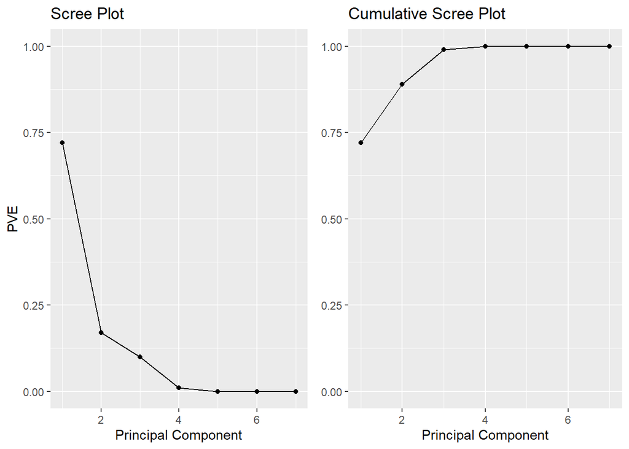

```r
#biplot
PC1 <-- df.scaled %*% phi[,1]
PC2 <- df.scaled %*% phi[,2]
PC <- data.frame(units = rownames(seed), PC1, PC2)
head(PC)
```

```
##   units          PC1       PC2
## 1     1 -0.316291277 0.7818009
## 2     2  0.003378106 1.9086530
## 3     3  0.458348123 1.9026788
## 4     4  0.590524599 1.9264659
## 5     5 -1.100280938 2.0631601
## 6     6  0.336012252 1.6330142
```

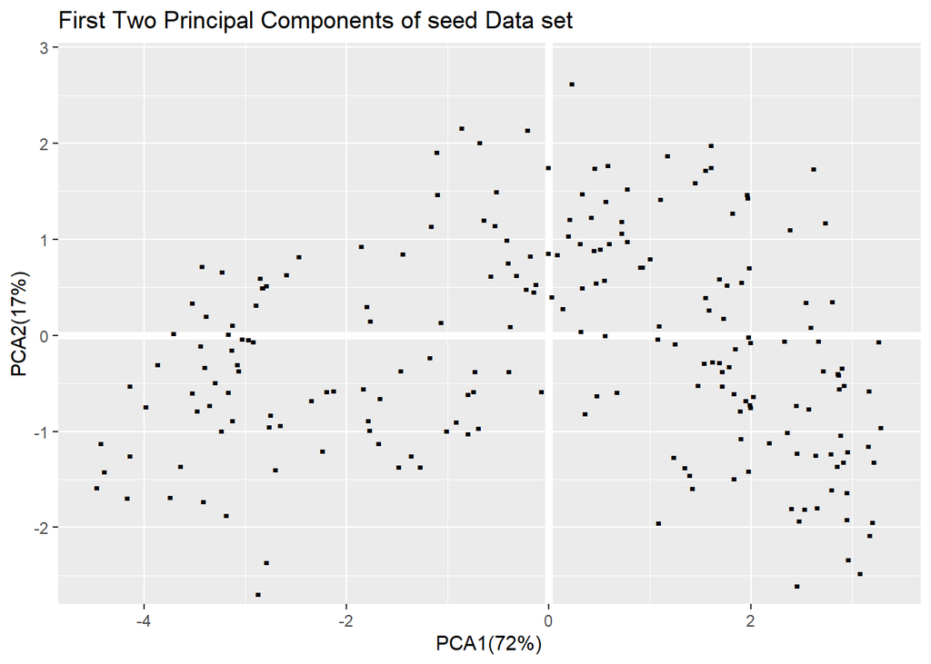

```r
ggplot(PC, aes(PC1, PC2)) +
  modelr::geom_ref_line(h = 0) +
  modelr::geom_ref_line(v = 0) +
  geom_text(aes(label="."), size = 9) +
  xlab("PCA1(72%)") +
  ylab("PCA2(17%)") +
  ggtitle("First Two Principal Components of seed Data set")
```

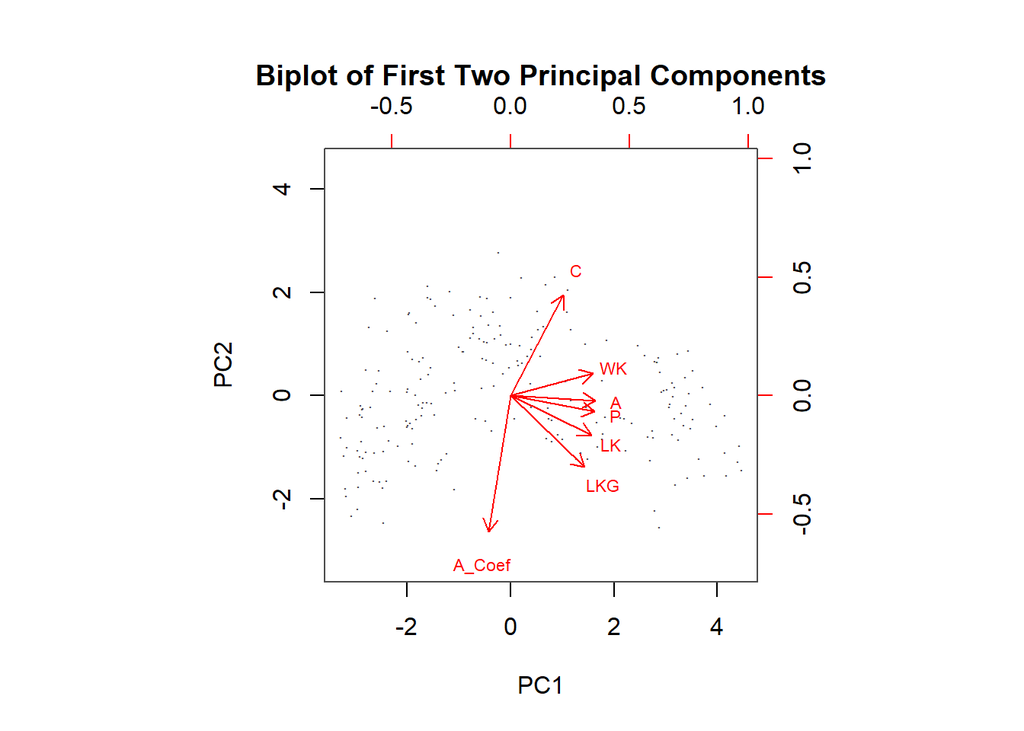

```r
# PCA biplot - fixed version
pr.out <- prcomp(seed[1:7], scale = TRUE)

pr.out$rotation[,1] <- -pr.out$rotation[,1]
pr.out$x[,1] <- -pr.out$x[,1]

biplot(pr.out,
       scale = 0,
       cex = 0.7,                   # dimensione testo/frecce
       col = c("gray30", "red"),    # punti grigi, variabili rosse
       xlabs = rep(".", nrow(seed)),# toglie i numeri delle etichette
       main = "Biplot of First Two Principal Components")
```

# CLUSTER ANALYSIS

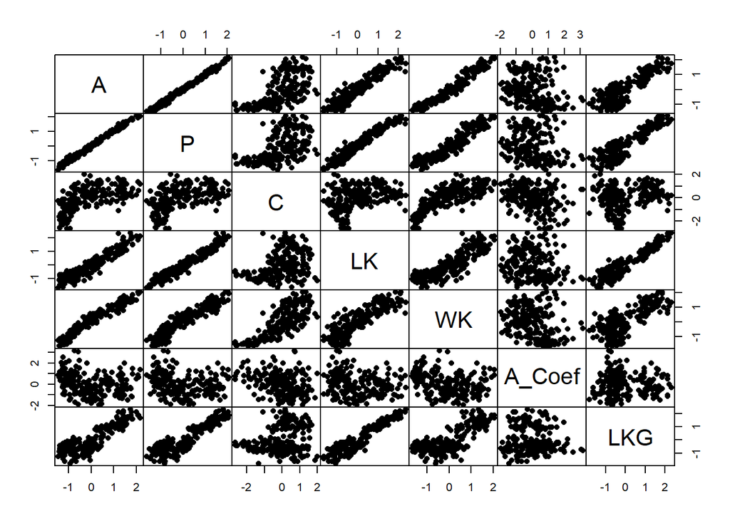

```r
# Remove target variable (8th column)
seed_notarget <- seed[ , -8]
df.scaled<-scale(seed_notarget)
pairs(df.scaled,gap=0,pch=16) #pairwise scatterplot matrix
```

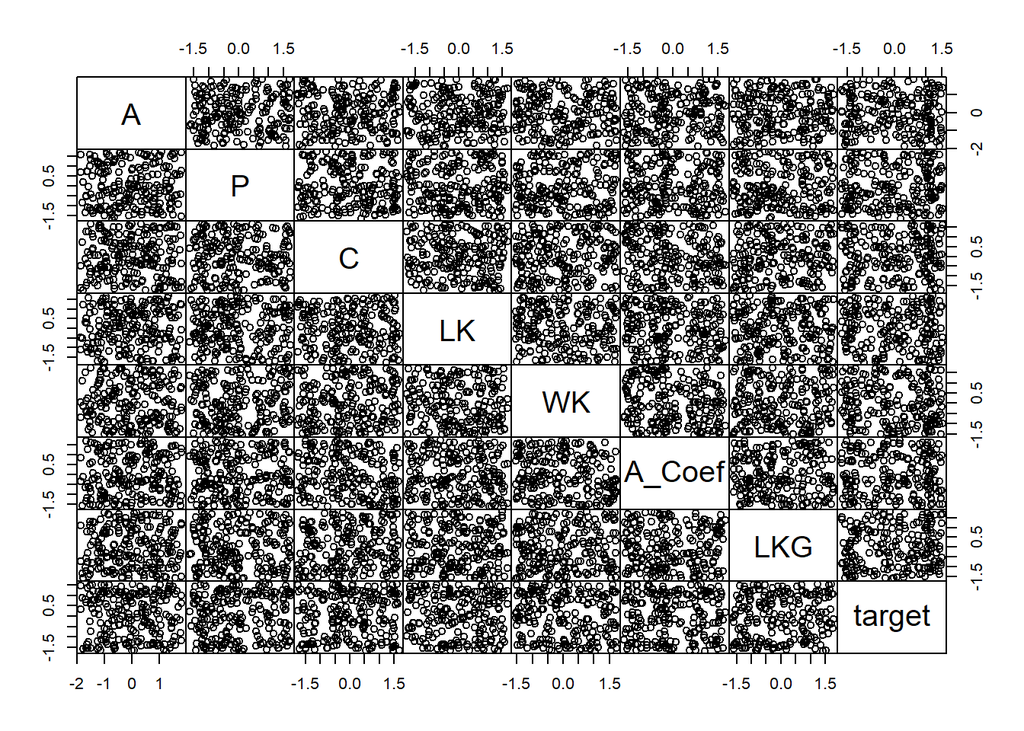

```r
set.seed(1)
random_seed <- apply(seed, 2,function(seed){runif(length(seed), min(seed), max(seed))})
random_seed<-as.data.frame(random_seed)
scaled.random_seed<-scale(random_seed)
pairs(scaled.random_seed,gap=0,pch=21)
```

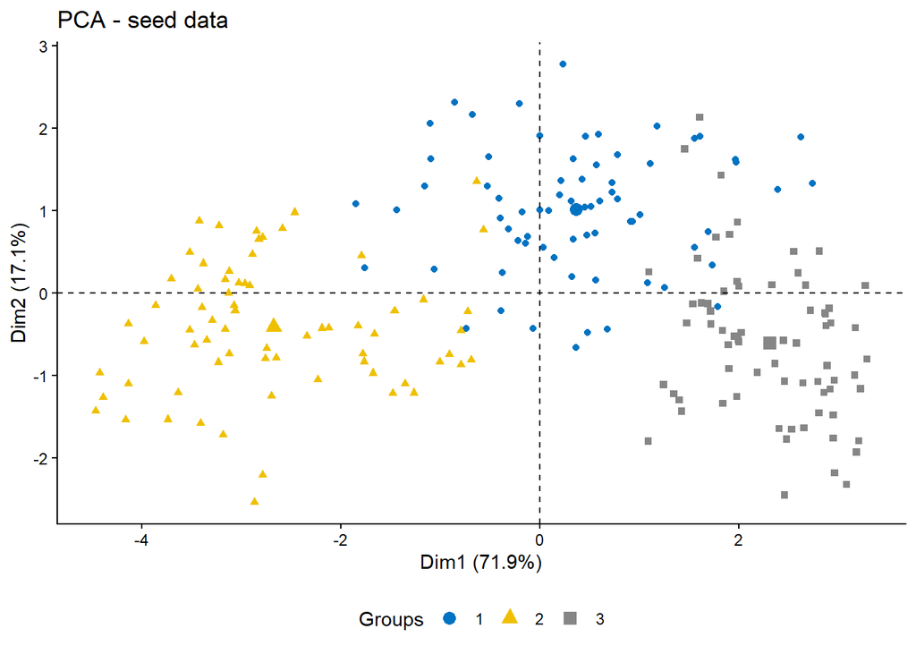

```r
# Plot the standardized df data

fviz_pca_ind(prcomp(df.scaled), title = "PCA - seed data",
             habillage = seed$target, palette = "jco",
             geom = "point", ggtheme = theme_classic(),
             legend = "bottom")
```

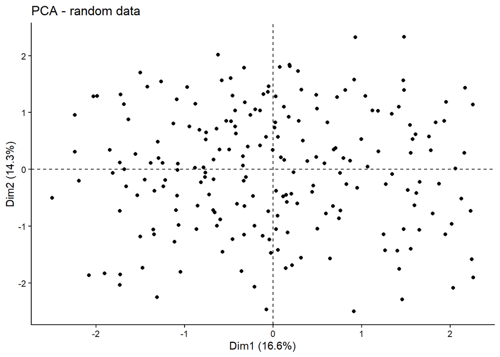

```r
# Plot the standardized df data
fviz_pca_ind(prcomp(scaled.random_seed), title = "PCA - random data",
              palette = "jco",
             geom = "point", ggtheme = theme_classic(),
             legend = "bottom")
```